# HRS 2016 - Cognition classification using profile mixture modeling

Authors

Affiliations

Douglas Tommet

Brown University, Department of Psychiatry and Human Behavior

Richard N. Jones

Brown University, Department of Psychiatry and Human Behavior, Department of Neurology

HRS/HCAP Team

HHH Team

Published

March 25, 2026

Abstract

**Objective:** This analysis report describes the classification of cognitive impairment (Normal, Mild Cognitive Impairment, Dementia) using profile mixture modeling. The goal is to classify individuals in the Core Health and Retirement Study using data available in the (2016) Core interview, but to do in a way that (1) uses information learned in the HRS/HCAP study (Manly et al., 2022; Farron et al, 2025) and (2) produces a probabilistic classification for cognitive level. The approach we describe accomplishes these goals, remains consistent with the *actuarial* approach to cognitive classification described by Jaq, Bondi and colleagues and used in Manly et al (2022), but discards the classification tree approach for an analytically derived classification model.

**Approach:**

*Step 1 - Data management:* We manage data (define subsamples – HRS age 65+ [n = 9,972], HRS/HCAP [n = 3,496], HRS/HCAP robust norms group [n = 1,787], HRS/HCAP validation sample [n = 50]), code analytic variables (cognitive indicators, functional impairment and self-report indicators, informant report indicators, HRS/HCAP classification results). No imputation for missing data, we’re using maximum likelihood.

*Step 2 - Model calibration:* We fit a profile mixture model to the HRS/HCAP sample and evaluate it using internal cross-validation. This model is estimated in the HRS/HCAP subsample (n = 3496), and using a knownclass mixture modeling approach with the HRS/HCAP classification results as the known class membership. The model is calibrated using a the Core of cognitive indicators and functional impairment indicators (e.g., IADL, ADL, self-report, informant report). Cognitive performance variables are regressed on the covariates (age, sex, race, ethnicity, education) with fixed parameter estimates derived from a preliminary model fit to only those individuals in the robust norms group. This model is evaluated using internal cross-validation. This evaluation uses as the criterion the knownclass variable, the result of the HRS/HCAP actuarial (manly-jones) classification, and offers a preview of the classification model developed in Step 3.

*Step 3 - Classification:* In the third step we use parameters of the *calibration model* – treating the parameters as fixed population values, apply it to the full HRS age 65+ sample using only data available to the Core sample. We refer to this as the *classification model*. The model uses only cognitive data, socio-demographics, and functional impairment, self-report, and informant data (i.e., no robust norms group information, no known class membership information). We and (3) evaluate the agreement with (a) the HRS/HCAP consensus panel sample (n = 50) and (b) other dementia classifications available in the HRS (Langa-Weir, Hudomiet). These comparisons are completed in the HRS 65+ sample. To contextualize the results of the classification model, we also evaluate the validity of new classification model and the Langa-Weir, and Hudomiet with the HRS/HCAP consensus panel reference standard (n = 50).

**End results**. A classification model that produces a classification *and a* probabilistic estimate of membership in HRS/HCAP “Normal”, “MCI”, and “Dementia” categories (n = 9,972), and information about the reliability (internal cross-validation) and validity (correspondence to reference standard diagnosis [n = 50] other algorithms [n = 9,972]).

# Use of terms

| **Terms** | **Meaning** |
| --- | --- |
| *Actuarial* | The first appearance of “actuarial neuropsychological” I can find in Google Scholar is attributable to Anthony et al (1980), but they refer to a history of the approach as described in the literature … |
| *Knownclass* | A knownclass model is a categorical latent variable modeling approach (e.g., latent class model, mixture model) where class membership is known. A knownclass model is analogous to a *supervised* learn… |
| **Manly-Jones algorithm** | Describes the approach to cognitive classification described in Manly et al (2022). This approach is a so-called *actuarial* classification, with that term attributed to Jak and Bondi and their collea… |
| *Mixture model* | A categorical latent variable modeling approach that includes continuous variables as class indicators. Contrast with a *latent class model*, which is a categorical latent variable modeling approach t… |
| **Robust norms group** and **normative reference group** | These terms are used interchangeably. The terms refer to a set of people who are believed to be free from the cognitive effects of brain injury and disease. These people – as a group – define the rang… |
| *Supervised* *vs. unsupervised* | Supervised learning is a type of predictive modeling that uses labeled data (the outcome of interest is already known for each case, i.e. predictive modeling). Unsupervised learning uses unlabeled dat… |

# Overall approach

We will use a *supervised latent profile model* trained with known class labels in HRS/HCAP (results of the Manly-Jones algorithm in the N=3,496 sample) to predict cognitive status in the broader HRS cohort (age 65+, n = 9,972). The model preserves the actuarial approach to classification while introducing a parametric latent structure, item-level covariate adjustment, and probabilistic scoring. A cartoon of the approach is show in Figure 1.

[figure not shown]

Figure 1: Calibration model - a supervised latent profile model

where:

| Latent Class (“c”) | Class membership fixed to HRS/HCAP classification during model calibration |
| --- | --- |
| Latent cognition | General cognitive performance (GCP), factor-analytic structure, we allow for class membership to be indicated by the mean and variance of the GCP, after limited control for the effect of sociodemograp… |
| Dependent variables | Observed cognitive test scores (e.g., vdlflf1z, vdwdimmz), ADLs, self-report, informant |
| Sociodemographic Covariates | Centered and interacted, included only to adjust indicator means and not to directly inform class membership |
| Missing data strategy | In general, missing data is handled analytically. The Jorm being observed only in those without cognitive performance data (and vice versa) indicator may require separate modeling of the Informant dat… |

We are building a supervised latent profile model for cognitive classification using:

- **Latent Class Regression** with known class labels (from the HRS/HCAP actuarial classification).
- **Multivariate cognitive and functional data** (profile indicators) to define latent class structure (Normal, MCI, Dementia).
- **Sociodemographic covariates** used not to predict class directly, but to adjust item means and thresholds.

The model is:

- Estimated in HRS/HCAP (with known class labels, n=3,496),
- Applied to Core HRS (with unknown class labels) for classification (n = 9,972),
- Designed to retain the structure and assumptions of actuarial classification, but expressed in a fully parametric latent variable modeling framework.

In psychometric terms, our approach can be described as a *supervised profile mixture model with structured measurement invariance*. We estimate latent classes using multivariate cognitive and functional profiles (profile mixture model), use known classifications to supervise training (supervised), allow item means and thresholds to vary by sociodemographic covariates (structured measurement invariance).

## Notable features of model

### Purposeful misspecification.

We do not include, in our initial model, model parameters that allow for estimation of class membership on the basis of sociodemographics. This is a deliberate choice: we want class membership “predicted” only by cognitive, functional, self-report, and informant data. It is true we correct for measurement differences (in the means/thresholds) of individual cognitive indicators according to sociodemographics, but the effect of these covariates in the class variable is blocked at the cognitive performance variable level. This is a misspecification because we know from Manly et al (2022) Table 2 that sociodemographics are associated with membership in MCI and Dementia groups. This misspecification may make our model fit sub-optimal. But, our main goal is to develop a classification model that maintains fidelity to the spirit of the actuarial classification approach, rather that to achieve an optimally fitting model.

### Covariate effects are fixed parameters estimated in a preliminary model.

A key component of the Jak/Bondi actuarial approach (and as used in Manly et al 2022) is the standardization of cognitive test scores across a set of covariates. In Manly et at (2022) cognitive ability estimates are regressed on age, sex, race, ethnicity, and educational attainment (and their two-way interactions) in a robust norms group. Cognitive impairment is defined using the residual from these regression equations. This is an attempt to operationalize the notion that *cognitive impairment should be lower than expected for the individual* when classifying persons according to criteria for mild cognitive impairment and dementia. Simply identifying persons with low cognition is not what we are interested in, because (a) cognitive abilities are widely distributed in healthy populations and (b) a definition of impairment that was based on low performance would mix up factors associated with low peak lifetime cognitive performance and those associated with risk, resistance, resilience, or compensation for brain disease and the cognitive consequences or brain disease. For example, the 2018 NIA/AA Research Criteria for MCI state that cognitive performance should be “below expected range for that individual based on all available information. This may be based on clinical judgment and/or on cognitive test performance (which may or may not be based on comparison to normative data with or without adjustments for age, education, occupation, sex, etc.)” and that cognitive performance in MCI is “usually in the impaired/abnormal range based on population norms, but this is not required as long as the performance is below the range expected for that individual.”(Jack et al, 2018, Table 3). Jack and his colleagues, in their announcement of the 2018 research framework, do not provide guidance on how to define “below the range expected for the individual”.

The Jak/Bondi actuarial approach – as used in Manly et al (2022) and elsewhere – identifies “below the expected range for the individual” using regression adjustment and residuals obtained from a *robust norms group*. The definition of cognitive impairment using covariates is handled in data processing step: (a) robust norms group membership is defined, (b) regression models of performance on sociodemographic factors are estimated in the robust norms group, (c) the models and their parameters are used to generate estimates of expected performance given sociodemographic factors for each individual in the target sample, (d) impairment is defined by comparing observed and expected performance in the form of a scaled residual.

[figure not shown]

Figure 2: Preliminary model for covariate effects estimated in robust norms sample

[figure not shown]

Figure 3: Approaches to constrained regression

In conclusion, our approach that involves a two-step calibration where covariate effects in the cognitive variables are estimated in the robust norms group, and used as fixed values in a subsequent classification model, is equivalent to using residuals given expected values derived from robust norms group equations as in Manly et al (2022). The omission of the scaling factor is not relevant, because we do not make inferences or classification decisions based on the scale of the cognitive performance indicators.

**Note**

Stata users can prove it to themselves:

```
clear
sysuse auto                           // use cars data set
gen robustsample = (rep78>2)          // robust norms sample good repair rating
standardize mpg if robustsample==1    // standardize to mean and sd in robust group
standardize weight if robustsample==1 // get standardize.ado at https://github.com/rnj0nes/Jones-ADO
standardize price                     // standardize in total sample
glm zmpg zweight if robustsample==1   // regression in robust norms group
scalar B0 = _b[_cons]                 // save constant or intercept term
scalar B1 = _b[zweight]               // save slope term
constraint 2 _cons = B0               // define constraints
constraint 3 zweight =  B1
gen pzmpg = B0 + B1*zweight           // linear predictor
gen resid = zmpg-pzmpg                // residual
glm zmpg zweight zprice , constraints(2 3) // constrained regression
glm zmpg zprice , offset(pzmpg)      // linear predictor as offset
glm resid zprice                     // regression of residual
```

R users are in a bind because there is no easy way to constrain parameters in R. The easiest approximate solution is to specify starting values and limit the iterations to 0.

## Important differences from the Manly-Jones algorithm

**No explicit decision tree.** The proposed model makes classifications analytically, and does not place a decision-tree like logic on the indicators to arrive at a classification. Parameters of the model are estimated (calibrated) to maximize agreement between the analytically-derived class assignments and the observed (knownclass) assignments derived from the Manly-Jones algorithm (aka the HRS/HCAP actuarial algorithm).

**Missing data.** There is no imputation of missing data. Since the entirety of the classification is performed analytically, we rely upon the maximum likelihood and Bayesian parameter estimation procedures that provide unbiased estimates under the assumption that the missing data mechanism conforms to the conditionally missing at random assumption. This approach is superior to a single value imputation strategy, even if the imputations are drawn stochastically.

**Socio-demographic adjustment occurs at the indicator level** rather than the construct level. The Manly-Jones algorithm applies sociodemographic corrections at the domain level, implicitly assuming these corrections are appropriate for every sub test. Our approach implements these corrections (or their analytic analog) at the individual test level.

## Classification model

Below is a cartoon of the classification model:

[figure not shown]

Figure 4: Classification model

When we use this model, either in cross-validation in the derivation sample (n = 3496) or in application to the full HRS 2016 age 65+ sample (n = 9972):

**All parameters are fixed to presumed population values.** These are those estimated in a particular cross-fold estimation for the assessment of classification model reliability, or the full sample estimation for the final analysis.

**Known class assignment is not included.** The model will be applied to data sets where these assignments are not observed.

**Prepare a scoring grid.** We will generate a grid of all possible values for the variables included in the model, and run that grid through the classification model. The resulting data set of variable values and class probabilities will be a handy look-up table for exporting the algorithm to other data sets (i.e., HRS data from 2000 to 2022 for a prevalence and incidence paper). This grid will be immense but data storage is cheap. An important consideration for this is numeric data (e.g., z-scores for standardized cognitive indicators) need to be truncated to a reasonable degree of precision in the *Data management step*.

# HRS 2016 and participant subgroups

The following diagram summarizes the relationships among some important subgroups of participants for this analysis.

**Sampling Weight Issue**

There are 79 people in HCAP who have a zero sampling weight in the HRS 2016 (`PWGT`). They are included as being in the sampling frame for this analysis.

[figure not shown]

Figure 5: Flow diagram for participants in planned analyses

Note: Refer to `PMM_033_Sample_identification.R`

## Analysis notes

**Covariate centering.** Sociodemographics are centered at age 70, education grade 12, and the complex survey-weighted means in the HRS/HCAP 2016 age 65+ subsample (n = 3,496) for Black or African-American vs all other race and ethnicity groups, Hispanic vs not-Hispanic, and female sex.

**Sample restriction.** Analyses, tables, and figures will be explicitly limited to the appropriate target sample (e.g., n = 9763, n = 3496, n = 50).

### Notes on weights: filters, subpopulation, weighted subpopulation

In complex survey data like HRS, filtering the dataset to a subpopulation (e.g., age 65+) and running an analysis as if this subset were a simple random sample leads to incorrect standard errors and potentially biased estimates. The correct approach is to use a *subpopulation analysis*, where the full design (weights, strata, clusters) is preserved, but the analysis is restricted to the subpopulation.

#### Key Points:

- In R (`survey` package): create a full `svydesign()` object using the full dataset, then apply `subset()` to restrict the analysis to the subpopulation.
- In Mplus: use the `SUBPOPULATION =` command, which allows you to include everyone in the data but restrict the estimation to a group (e.g., age ≥ 65) without dropping observations.
- Subpopulation routines ensure correct standard errors by preserving information about the full sample design.

#### Subpopulation Analysis in R Using the `survey` Package

The `survey` package in R provides full support for subpopulation analysis in complex survey data. The recommended approach is:

```
library(survey)


attr(PMM_41$inConsensus, "label") <- "Indicator for HRS/HCAP consensuspaneldx subpopulation"
attr(PMM_41$inConsensus, "label") <- "Normalized sampling weight for consensuspaneldx"


# Define the full survey design
hrs_design <- svydesign(
  ids = ~psuvar,
  strata = ~stratavar,
  weights = ~weightvar,
  data = hrs_full,
  nest = TRUE
)

# Restrict analysis to a subpopulation (e.g., age 65+)
h65_design <- subset(hrs_design, age >= 65)

# Example analysis
svymean(~cog_score, design = h65_design)
```

This approach preserves the full information about the sample design, even though the estimation is limited to the subset. It avoids the bias introduced by dropping non-subpopulation cases from the dataset.

### What to do when using the HCAP Consensus sample

```
library(survey)

# Define survey design using full data
design <- svydesign(
  ids = ~SECU,
  strata = ~STRATUM,
  weights = ~HCAP16WGTR_consensus,
  data = PMM_45,
  nest = TRUE
)
# Use subset() to restrict to subpopulation while retaining full design
design_consensus <- subset(design_full, inConsensus == 1)
# Now proceed with svymean(), svyglm(), etc. on subpop_design
svymean(~age, design = design_consensus)
svyglm(outcome ~ predictor, design = design_consensus)
```

#### Why Not Just Filter the Data?

If you were to do:

```
subset_data <- hrs_full %>% filter(age >= 65)
subset_design <- svydesign(ids = ~psuvar, strata = ~stratavar, weights = ~weightvar, data = subset_data)
```

You would be telling R that the `subset_data` sample is a full probability sample, when in fact it is a subpopulation from a larger design. This would underestimate standard errors and potentially bias point estimates.

#### Notes on Variance Estimation

- Functions like `svymean()` and `svyglm()` will automatically compute standard errors correctly for subpopulations if `subset()` is used.
- Use `svyby()` for multiple subgroups.

This logic is conceptually the same as the `SUBPOPULATION =` feature in Mplus.

```
svyby(~cog_score, ~sex, h65_design, svymean)
```

## Plan for cross-validation

The goal of the internal cross-validation is to evaluate the internal validity of a supervised classifier (e.g., a profile mixture model) by assessing how well it predicts class membership when applied to held-out data, with 3 outcome classes. These analyses will be conducted as part of the derivation of the *calibration model*, and conducted in the n = 3496 sample.

The basic approach is:

1. Split the labeled data (n = 3,496) into $K = 10$ roughly equal parts (folds), stratifying on labeled class membership (Normal, MCI, Dementia) to maintain the observed class proportions in each fold.
2. Iteratively train on $K - 1$ folds, and test on the remaining fold.
3. Repeat until every fold has served once as the test set.
4. Aggregate results to assess classification performance.

### Details

1. Define folds where K=10, stratify by class to ensure folds contain similar proportions of Normal, MCI, Dementia.
2. For each fold (i = 1 to K):
   - Training set = K–1 folds
   - Use known class labels to train your model (e.g., estimate mixture model parameters).
   - Test set = the i-th fold. **Use fixed parameters from training set and leave out known class membership**
3. Evaluation. For each person in the test fold, save from Mplus:
   - Class probabilities: P(Normal), P(MCI), P(Dementia)
   - Most likely class: Class with highest probability
   - Record predicted and actual (true) class.

### Evaluation Metrics

Since we have 3 classes, we use multiclass evaluation metrics:

**1. Confusion Matrix**

Shows counts of predictions vs. true labels:

```
           Predicted
        | N   MCI  Dem
--------+-------------
True N  | a   b    c
True MCI| d   e    f
True Dem| g   h    i
```

### Metrics:

**Overall accuracy**: $\frac{a + e + i}{\text{total}}$

**Per-class sensitivity (recall):**

Sens(Normal): $\frac{a}{a + b + c}$

Sens(MCI): $\frac{e}{d + e + f}$

Sens(Dementia): $\frac{i}{g + h + i}$

**Per-class precision (PPV) and F1 scores:**

PPV(Normal): $\frac{a}{a + d + g}$

PPV(MCI): $\frac{e}{b + e + h}$

PPV(Dementia): $\frac{i}{c + f + i}$

**Weighted Kappa** (using quadratic weights)

### Calibration:

For each class, plot predicted vs. observed probabilities in bins (e.g., deciles of P(Dementia)), and use a Brier score to assess calibration quality.

The Brier score is used to assess the accuracy of probabilistic predictions. For a single observation, the Brier score is:

$$\text{Brier} = \sum_{g=1}^G \left( \hat{p}_g - y_g \right)^2$$

Where:

$G$ = number of classes (e.g., 3: Normal, MCI, Dementia)

$\hat{p}_g$ = predicted probability that the observation belongs to class $g$

$y_g$ = indicator (1 if true class is $g$, else 0)

Then average over all N observations:

$$\text{Brier Score (Multiclass)} = \frac{1}{N} \sum_{i=1}^N \sum_{g=1}^G \left( \hat{p}_{ig} - y_{ig} \right)^2$$

Where the range is 0 (perfect) to 2 (for 3-class), and lower is better. Some authors will report the Bier score normalized (0–1).

$$\text{Brier}_{\text{normalized}} = \frac{\text{Brier}_{\text{raw}}}{2/3}$$

where $2/3$ is $(G-1)/G$.

# Compiling data

Most of the data processing was handled in a previous workflow, and not documented here.

Please refer to `PMM_031_Pull_data.R`

Here are the contents of the working data file

Variables and Labels in PMM_31

| variable | label |
| --- | --- |
| HHID | HOUSEHOLD IDENTIFICATION NUMBER |
| PN | RESPONDENT PERSON IDENTIFICATION NUMBER |
| SECU | SAMPLING ERROR COMPUTATION UNIT |
| STRATUM | STRATUM ID |
| PWGTR | 2016 WEIGHT: RESPONDENT LEVEL |
| HCAP16WGTR | HCAP 2016 WEIGHT: RESPONDENT LEVEL |
| samplingP | Probability of selection into adjudication |
| PINSAMP | 2016 SAMPLE STATUS |
| PIWWAVE | 2016 WHETHER INTERVIEWED IN THE WAVE |
| PIWYEAR | 2016 INTERVIEW YEAR |
| PMARST | 2016 MARITAL STATUS |
| PNURSHM | 2016 NURSING HOME STATUS |
| PPROXY | 2016 PROXY TYPE STATUS |
| rage | R CURRENT AGE CALCULATION |
| PA019 | R CURRENT AGE CALCULATION |
| PAGE | AGE AT 2016 INTERVIEW |
| female | Female from trk2022tr_r |
| black | Black or African-American (not Hispanic) from trk2022tr_r |
| hisp | Hispanic from trk2022tr_r |
| SCHLYRS |  |
| HISPANIC | HISPANICITY TYPE |
| RACE | RACE/ETHNICITY |
| vdori | Orientation to Time - number correct |
| vdlfl1z | Animal naming (correct - errors) |
| vdlfl2 | Object naming - Scissors, cactus |
| vdlfl3 | Naming - President, Vice-president |
| vdwdimmz | Word recall - Immediate |
| vdwddelz | Word recall - Delayed |
| vdexf7z | Number series |
| vdsevens | Serial 7's - Number correct |
| vdcount | Count backwards from 20 |
| rPG014 | ADL: Difficulty Dressing |
| rPG021 | ADL: Difficulty Bathing |
| rPG023 | ADL: Difficulty Eating |
| rPG030 | ADL: Difficulty Using Toilet |
| rPG040 | IADL: Difficulty Using Maps |
| rPG041 | IADL: Difficulty Meal Prep |
| rPG044 | IADL: Difficulty Grocery Shopping |
| rPG047 | IADL: Difficulty Making Phone Calls |
| rPG050 | IADL: Difficulty Taking Meds |
| rPG059 | IADL: Difficulty Managing Money |
| iadl_imp | Sum of ADL/IADL impairments |
| PG013 | CHKPNT: COUNT OF G001 THROUGH G012 |
| PG014 | DIFFICULTY- DRESSING |
| PG021 | DIFFICULTY BATHING |
| PG023 | DIFFICULTY EATING |
| PG030 | DIFFICULTY USING TOILET |
| PG040 | DIFFICULTY- USING MAPS |
| PG041 | IADL MEAL PREPARATION DIFFICULTY |
| PG044 | IADL GROC SHOP DIFFICULTY |
| PG047 | IADL MAKING PHONE CALLS DIFFICULTY |
| PG050 | IADL TAKING MEDICATION DIFFICULTY |
| PG059 | IADL MANAGING MONEY DIFFICULTY |
| PD102 | RATE MEMORY PAST |
| jorm | Jorm score (HRS) |
| normexcld | Excluded from normative sample |
| vs1hcapdx | HRS HCAP Dementia and MCI Classification (BPV version, HRS HCAP variable set 1) |
| vs1hcapdxeap | HRS HCAP Dementia and MCI Classification (EAP version, HRS HCAP variable set 1) |
| consensuspaneldx | consensuspaneldx |
| cogfunction2016 | 2016: Cognition Category: 1=Normal, 2=CIND, 3=Demented |
| PrDem | Probability of dementia, point estimate |
| PrCIND | Probability of CIND, point estimate |
| PrNorm | Probability of normal cognition, point estimate |
| Cog | Latent cognition, point estimate |
| CogSd | Latent cognition, std of estimate |
| Hudomiet_classification | Hudomiet classification by highest class proportion |
| SCHLYRSimp | Number of years in school (imputed) |
| DEGREE | HIGHEST DEGREE OF EDUCATION |

## Descriptives in analysis sample

This report is limited to those age 65 and older, and either in HCAP or have a non-zero 2016 Core interview sampling weight (`inHcap==1 | (age65up==1 & nonzeroweight==1))`)

Data summary

| Name | haven::zap_label(n9763) |
| --- | --- |
| Number of rows | 9763 |
| Number of columns | 71 |
| _______________________ |  |
| Column type frequency: |  |
| character | 2 |
| numeric | 69 |
| ________________________ |  |
| Group variables | None |

**Variable type: character**

| skim_variable | n_missing | complete_rate | min | max | empty | n_unique | whitespace |
| --- | --- | --- | --- | --- | --- | --- | --- |
| HHID | 0 | 1 | 6 | 6 | 0 | 7399 | 0 |
| PN | 0 | 1 | 3 | 3 | 0 | 14 | 0 |

**Variable type: numeric**

| skim_variable | n_missing | complete_rate | mean | sd | p0 | p25 | p50 | p75 | p100 | hist |
| --- | --- | --- | --- | --- | --- | --- | --- | --- | --- | --- |
| SECU | 0 | 1.00 | 1.51 | 0.50 | 1.00 | 1.00 | 2.00 | 2.00 | 2.00 | ▇▁▁▁▇ |
| STRATUM | 0 | 1.00 | 30.06 | 15.19 | 1.00 | 18.00 | 32.00 | 43.00 | 79.00 | ▅▆▇▂▁ |
| PWGTR | 0 | 1.00 | 4941.63 | 3614.38 | 0.00 | 2387.00 | 4064.00 | 5936.00 | 28961.00 | ▇▂▁▁▁ |
| HCAP16WGTR | 6293 | 0.36 | 14298.28 | 10730.18 | 756.00 | 6723.25 | 11203.00 | 17902.25 | 59020.00 | ▇▃▂▁▁ |
| samplingP | 6442 | 0.34 | 0.01 | 0.03 | 0.00 | 0.00 | 0.00 | 0.01 | 0.12 | ▇▁▁▁▁ |
| PINSAMP | 0 | 1.00 | 1.00 | 0.00 | 1.00 | 1.00 | 1.00 | 1.00 | 1.00 | ▁▁▇▁▁ |
| PIWWAVE | 0 | 1.00 | 1.00 | 0.00 | 1.00 | 1.00 | 1.00 | 1.00 | 1.00 | ▁▁▇▁▁ |
| PIWYEAR | 0 | 1.00 | 2016.16 | 0.36 | 2016.00 | 2016.00 | 2016.00 | 2016.00 | 2018.00 | ▇▁▂▁▁ |
| PMARST | 0 | 1.00 | 1.85 | 0.98 | 1.00 | 1.00 | 1.00 | 3.00 | 5.00 | ▇▂▅▁▁ |
| PNURSHM | 0 | 1.00 | 4.93 | 0.48 | 1.00 | 5.00 | 5.00 | 5.00 | 5.00 | ▁▁▁▁▇ |
| PPROXY | 0 | 1.00 | 4.80 | 0.83 | 1.00 | 5.00 | 5.00 | 5.00 | 5.00 | ▁▁▁▁▇ |
| rage | 0 | 1.00 | 75.76 | 7.57 | 65.00 | 69.00 | 75.00 | 81.00 | 107.00 | ▇▇▃▁▁ |
| PA019 | 0 | 1.00 | 75.76 | 7.57 | 65.00 | 69.00 | 75.00 | 81.00 | 107.00 | ▇▇▃▁▁ |
| PAGE | 0 | 1.00 | 75.75 | 7.58 | 55.00 | 69.00 | 75.00 | 81.00 | 107.00 | ▁▇▇▂▁ |
| female | 0 | 1.00 | 0.59 | 0.49 | 0.00 | 0.00 | 1.00 | 1.00 | 1.00 | ▆▁▁▁▇ |
| black | 0 | 1.00 | 0.16 | 0.37 | 0.00 | 0.00 | 0.00 | 0.00 | 1.00 | ▇▁▁▁▂ |
| hisp | 0 | 1.00 | 0.11 | 0.32 | 0.00 | 0.00 | 0.00 | 0.00 | 1.00 | ▇▁▁▁▁ |
| SCHLYRS | 24 | 1.00 | 12.64 | 3.28 | 0.00 | 12.00 | 12.00 | 15.00 | 17.00 | ▁▁▂▇▇ |
| HISPANIC | 0 | 1.00 | 4.59 | 1.16 | 0.00 | 5.00 | 5.00 | 5.00 | 5.00 | ▁▁▁▁▇ |
| RACE | 0 | 1.00 | 1.51 | 1.41 | 0.00 | 1.00 | 1.00 | 1.00 | 7.00 | ▇▂▁▁▁ |
| vdori | 571 | 0.94 | 3.64 | 0.75 | 0.00 | 3.00 | 4.00 | 4.00 | 4.00 | ▁▁▁▂▇ |
| vdlfl1z | 637 | 0.93 | 0.17 | 0.08 | 0.00 | 0.11 | 0.16 | 0.22 | 1.00 | ▇▃▁▁▁ |
| vdlfl2 | 571 | 0.94 | 1.90 | 0.32 | 0.00 | 2.00 | 2.00 | 2.00 | 2.00 | ▁▁▁▁▇ |
| vdlfl3 | 572 | 0.94 | 1.62 | 0.55 | 0.00 | 1.00 | 2.00 | 2.00 | 2.00 | ▁▁▃▁▇ |
| vdwdimmz | 634 | 0.94 | 0.50 | 0.17 | 0.00 | 0.40 | 0.50 | 0.60 | 1.00 | ▂▆▇▃▁ |
| vdwddelz | 635 | 0.93 | 0.39 | 0.21 | 0.00 | 0.30 | 0.40 | 0.50 | 1.00 | ▅▃▇▅▁ |
| vdexf7z | 1867 | 0.81 | 0.61 | 0.19 | 0.00 | 0.53 | 0.62 | 0.73 | 1.00 | ▁▁▆▇▂ |
| vdsevens | 571 | 0.94 | 3.31 | 1.77 | 0.00 | 2.00 | 4.00 | 5.00 | 5.00 | ▅▂▂▃▇ |
| vdcount | 608 | 0.94 | 0.92 | 0.27 | 0.00 | 1.00 | 1.00 | 1.00 | 1.00 | ▁▁▁▁▇ |
| rPG014 | 2594 | 0.73 | 0.18 | 0.38 | 0.00 | 0.00 | 0.00 | 0.00 | 1.00 | ▇▁▁▁▂ |
| rPG021 | 4065 | 0.58 | 0.17 | 0.37 | 0.00 | 0.00 | 0.00 | 0.00 | 1.00 | ▇▁▁▁▂ |
| rPG023 | 4068 | 0.58 | 0.08 | 0.27 | 0.00 | 0.00 | 0.00 | 0.00 | 1.00 | ▇▁▁▁▁ |
| rPG030 | 4074 | 0.58 | 0.13 | 0.34 | 0.00 | 0.00 | 0.00 | 0.00 | 1.00 | ▇▁▁▁▁ |
| rPG040 | 851 | 0.91 | 0.17 | 0.37 | 0.00 | 0.00 | 0.00 | 0.00 | 1.00 | ▇▁▁▁▂ |
| rPG041 | 532 | 0.95 | 0.08 | 0.28 | 0.00 | 0.00 | 0.00 | 0.00 | 1.00 | ▇▁▁▁▁ |
| rPG044 | 556 | 0.94 | 0.10 | 0.31 | 0.00 | 0.00 | 0.00 | 0.00 | 1.00 | ▇▁▁▁▁ |
| rPG047 | 114 | 0.99 | 0.06 | 0.24 | 0.00 | 0.00 | 0.00 | 0.00 | 1.00 | ▇▁▁▁▁ |
| rPG050 | 20 | 1.00 | 0.05 | 0.23 | 0.00 | 0.00 | 0.00 | 0.00 | 1.00 | ▇▁▁▁▁ |
| rPG059 | 533 | 0.95 | 0.08 | 0.26 | 0.00 | 0.00 | 0.00 | 0.00 | 1.00 | ▇▁▁▁▁ |
| iadl_imp | 0 | 1.00 | 0.86 | 1.76 | 0.00 | 0.00 | 0.00 | 1.00 | 10.00 | ▇▁▁▁▁ |
| PG013 | 0 | 1.00 | 3.02 | 2.89 | 0.00 | 0.00 | 2.00 | 5.00 | 10.00 | ▇▂▂▂▁ |
| PG014 | 2577 | 0.74 | 4.33 | 1.51 | 1.00 | 5.00 | 5.00 | 5.00 | 8.00 | ▂▁▇▁▁ |
| PG021 | 4055 | 0.58 | 4.35 | 1.49 | 1.00 | 5.00 | 5.00 | 5.00 | 8.00 | ▂▁▇▁▁ |
| PG023 | 4055 | 0.58 | 4.70 | 1.08 | 1.00 | 5.00 | 5.00 | 5.00 | 8.00 | ▁▁▇▁▁ |
| PG030 | 4055 | 0.58 | 4.50 | 1.35 | 1.00 | 5.00 | 5.00 | 5.00 | 8.00 | ▁▁▇▁▁ |
| PG040 | 12 | 1.00 | 4.65 | 1.55 | 1.00 | 5.00 | 5.00 | 5.00 | 9.00 | ▂▁▇▁▁ |
| PG041 | 12 | 1.00 | 4.83 | 1.16 | 1.00 | 5.00 | 5.00 | 5.00 | 9.00 | ▁▁▇▁▁ |
| PG044 | 12 | 1.00 | 4.74 | 1.29 | 1.00 | 5.00 | 5.00 | 5.00 | 8.00 | ▁▁▇▁▁ |
| PG047 | 12 | 1.00 | 4.80 | 0.95 | 1.00 | 5.00 | 5.00 | 5.00 | 9.00 | ▁▁▇▁▁ |
| PG050 | 12 | 1.00 | 4.82 | 0.91 | 1.00 | 5.00 | 5.00 | 5.00 | 9.00 | ▁▁▇▁▁ |
| PG059 | 12 | 1.00 | 4.84 | 1.13 | 1.00 | 5.00 | 5.00 | 5.00 | 9.00 | ▁▁▇▁▁ |
| PD102 | 571 | 0.94 | 2.25 | 0.53 | 1.00 | 2.00 | 2.00 | 3.00 | 9.00 | ▇▃▁▁▁ |
| jorm | 9193 | 0.06 | 3.59 | 0.80 | 1.00 | 3.00 | 3.18 | 4.25 | 5.00 | ▁▁▇▂▃ |
| normexcld | 6293 | 0.36 | 0.49 | 0.50 | 0.00 | 0.00 | 0.00 | 1.00 | 1.00 | ▇▁▁▁▇ |
| vs1hcapdx | 6293 | 0.36 | 1.46 | 0.69 | 1.00 | 1.00 | 1.00 | 2.00 | 3.00 | ▇▁▃▁▂ |
| vs1hcapdxeap | 6293 | 0.36 | 1.45 | 0.68 | 1.00 | 1.00 | 1.00 | 2.00 | 3.00 | ▇▁▃▁▁ |
| consensuspaneldx | 9714 | 0.01 | 2.02 | 0.78 | 1.00 | 1.00 | 2.00 | 3.00 | 3.00 | ▆▁▇▁▆ |
| cogfunction2016 | 0 | 1.00 | 1.39 | 0.65 | 1.00 | 1.00 | 1.00 | 2.00 | 3.00 | ▇▁▂▁▁ |
| PrDem | 0 | 1.00 | 0.09 | 0.24 | 0.00 | 0.00 | 0.00 | 0.01 | 1.00 | ▇▁▁▁▁ |
| PrCIND | 0 | 1.00 | 0.26 | 0.29 | 0.00 | 0.01 | 0.11 | 0.49 | 0.95 | ▇▂▂▂▂ |
| PrNorm | 0 | 1.00 | 0.66 | 0.38 | 0.00 | 0.31 | 0.84 | 0.98 | 1.00 | ▃▁▁▂▇ |
| Cog | 0 | 1.00 | 1.26 | 0.85 | -3.82 | 0.83 | 1.38 | 1.84 | 3.67 | ▁▁▂▇▁ |
| CogSd | 0 | 1.00 | 0.38 | 0.04 | 0.25 | 0.35 | 0.36 | 0.39 | 0.58 | ▁▇▂▂▁ |
| Hudomiet_classification | 0 | 1.00 | 1.40 | 0.63 | 1.00 | 1.00 | 1.00 | 2.00 | 3.00 | ▇▁▃▁▁ |
| SCHLYRSimp | 0 | 1.00 | 12.64 | 3.28 | 0.00 | 12.00 | 12.00 | 15.00 | 17.00 | ▁▁▂▇▇ |
| DEGREE | 0 | 1.00 | 2.24 | 1.65 | 0.00 | 2.00 | 2.00 | 3.00 | 9.00 | ▃▇▃▁▁ |
| nonzeroweight | 0 | 1.00 | 0.99 | 0.09 | 0.00 | 1.00 | 1.00 | 1.00 | 1.00 | ▁▁▁▁▇ |
| inHCAP | 0 | 1.00 | 0.36 | 0.48 | 0.00 | 0.00 | 0.00 | 1.00 | 1.00 | ▇▁▁▁▅ |
| age65up | 0 | 1.00 | 1.00 | 0.00 | 1.00 | 1.00 | 1.00 | 1.00 | 1.00 | ▁▁▇▁▁ |

## Data cleaning

### ADL indicators

The descriptives report above shows a lot of missing data in the ADLs. What’s up with that?

This is from the codebook

```
==========================================================================================


         IF ((((SecA.ContinuInterview.A218_AgeGreaterThan17 > 17) OR
         (SecA.ContinuInterview.A019_RAge > 17)) AND (RVARS.Z145_TypeExit_V <>
         NEWPOSTEXIT)) AND (RVARS.Z145_TypeExit_V <> FIRSTREPEATPOST)) AND
         (RVARS.Z145_TypeExit_V <> SECREPEATPOST) THEN

         IF NOT (piRvarsZ145_TypeExit_V IN [NEWPOSTEXIT, FIRSTREPEATPOST,
         SECREPEATPOST]) THEN

         IF (SecG.ADL.G013TNagiCkpt_A > 0) THEN

         IF (SecG.ADL.G129TDaysInBed_A < 86) OR SecG.ADL.G129TDaysInBed_A = EMPTY THEN


         - - - - - - - - - - - - - - - - - - - - - - - - - - - - - - - - - - - - - - - - -
PG014                         DIFFICULTY- DRESSING
         Section: G     Level: Respondent      Type: Numeric    Width: 1   Decimals: 0
         Ref: SecG.ADL.G014_DiffDress

         Here are a few more everyday activities. Please tell me if you have any
         difficulty with these because of a physical, mental, emotional or memory
         problem. Again exclude any difficulties you expect to last less than three
         months.

         Because of a health or memory problem do you have any difficulty with dressing,
         including putting on shoes and socks?

         .................................................................................
          2352           1.  YES
         10875           5.  NO
            52           6.  [IF VOL] CAN'T DO
            12           7.  [IF VOL] DON'T DO
            10           8.  DK (Don't Know); NA (Not Ascertained)
             2           9.  RF (Refused)
          7609       Blank.  INAP (Inapplicable); Partial Interview


==========================================================================================
```

According to the codebook, the blanks imply a partial interview, but hidden in the gobledygook above the variable report is this line `IF (SecG.ADL.G013TNagiCkpt_A > 0)`, which implies that the variable is not asked if `SecG.ADL.G013` is equal to 0. Variable `G013` is

==========================================================================================

```
     ASSIGN: G013TNagiCkpt_A := 0:IF ((((SecA.ContinuInterview.A218_AgeGreaterThan17
     > 17) OR (SecA.ContinuInterview.A019_RAge > 17)) AND (RVARS.Z145_TypeExit_V <>
     NEWPOSTEXIT)) AND (RVARS.Z145_TypeExit_V <> FIRSTREPEATPOST)) AND
     (RVARS.Z145_TypeExit_V <> SECREPEATPOST) THEN
     IF NOT (piRvarsZ145_TypeExit_V IN [NEWPOSTEXIT, FIRSTREPEATPOST,
     SECREPEATPOST]) THEN

     - - - - - - - - - - - - - - - - - - - - - - - - - - - - - - - - - - - - - - - - -
```

PG013 CHKPNT: COUNT OF G001 THROUGH G012 Section: G Level: Respondent Type: Numeric Width: 2 Decimals: 0 Ref: SecG.ADL.G013TNagiCkpt_A

```
     .................................................................................

     -----------------------------------------------------------------
          N      Min         Max          Mean            SD    Miss
      20912        0          10          2.59          2.90       0
     -----------------------------------------------------------------
```

==========================================================================================

…its the count of mobility limitations, in the 2016 wave these are `PG001-PG012`. The skip logic is supported in the [*Documentation of Physical Functioning* (2004) report](https://hrs.isr.umich.edu/sites/default/files/biblio/dr-008_0.pdf):

> In later waves of the HRS and AHEAD, people who had no problems with mobility, strength, and fine motor skills were not asked about ADLs. The HRS and AHEAD staff adopted these skip patterns based on their analyses showing that respondents tended to first lose the ability to perform tasks involving considerable mobility and strength, then the ability to perform tasks involving moderate mobility and strength, and lastly, the ability to do IADLs and ADLs. Analysts should consult the codebooks for each wave of the study to determine when skip patterns were used.

File `PMM_041_Data_cleaning_functional_items.R` uses the skip logic to impute 0’s according to the skip logic. Even if our earlier workflow handled the skip logic appropriately when making the `iadl_imp` variable, we might use the indivdiual adls/iadls in the classification model.

### IADL Indicators

I also revised the mapping of non-response codes to the IADL indicators relative to previous data handling

| IADL Core Response | Analytic Variable |
| --- | --- |
| 1. YES | 1 (impairment) |
| 5. NO | 0 (no impairment) |
| 6. [IF VOL] CAN’T DO | 1 (impairment) |
| 7. [IF VOL] DON’T DO | NA (missing) |
| 8. DK (Don’t Know); NA (Not Ascertained) | NA (missing) |
| 9. RF (Refused) | 1 (impairment) |
| Blank. INAP (Inapplicable); Partial Interview | NA (missing) |

**Updated descriptives with new ADL and IADL indicators**

The `rPG###` variables are removed, the new `nPG###` variables are new recodes that assign 0s for skip missing. The descriptives below are for the `age65up==1` sample.

Data summary

| Name | dplyr::filter(…) |
| --- | --- |
| Number of rows | 9763 |
| Number of columns | 61 |
| _______________________ |  |
| Column type frequency: |  |
| character | 2 |
| numeric | 59 |
| ________________________ |  |
| Group variables | None |

**Variable type: character**

| skim_variable | n_missing | complete_rate | min | max | empty | n_unique | whitespace |
| --- | --- | --- | --- | --- | --- | --- | --- |
| HHID | 0 | 1 | 6 | 6 | 0 | 7399 | 0 |
| PN | 0 | 1 | 3 | 3 | 0 | 14 | 0 |

**Variable type: numeric**

| skim_variable | n_missing | complete_rate | mean | sd | p0 | p25 | p50 | p75 | p100 | hist |
| --- | --- | --- | --- | --- | --- | --- | --- | --- | --- | --- |
| SECU | 0 | 1.00 | 1.51 | 0.50 | 1.00 | 1.00 | 2.00 | 2.00 | 2.00 | ▇▁▁▁▇ |
| STRATUM | 0 | 1.00 | 30.06 | 15.19 | 1.00 | 18.00 | 32.00 | 43.00 | 79.00 | ▅▆▇▂▁ |
| PWGTR | 0 | 1.00 | 4941.63 | 3614.38 | 0.00 | 2387.00 | 4064.00 | 5936.00 | 28961.00 | ▇▂▁▁▁ |
| HCAP16WGTR | 6293 | 0.36 | 14298.28 | 10730.18 | 756.00 | 6723.25 | 11203.00 | 17902.25 | 59020.00 | ▇▃▂▁▁ |
| samplingP | 6442 | 0.34 | 0.01 | 0.03 | 0.00 | 0.00 | 0.00 | 0.01 | 0.12 | ▇▁▁▁▁ |
| PINSAMP | 0 | 1.00 | 1.00 | 0.00 | 1.00 | 1.00 | 1.00 | 1.00 | 1.00 | ▁▁▇▁▁ |
| PIWWAVE | 0 | 1.00 | 1.00 | 0.00 | 1.00 | 1.00 | 1.00 | 1.00 | 1.00 | ▁▁▇▁▁ |
| PIWYEAR | 0 | 1.00 | 2016.16 | 0.36 | 2016.00 | 2016.00 | 2016.00 | 2016.00 | 2018.00 | ▇▁▂▁▁ |
| PMARST | 0 | 1.00 | 1.85 | 0.98 | 1.00 | 1.00 | 1.00 | 3.00 | 5.00 | ▇▂▅▁▁ |
| PNURSHM | 0 | 1.00 | 4.93 | 0.48 | 1.00 | 5.00 | 5.00 | 5.00 | 5.00 | ▁▁▁▁▇ |
| PPROXY | 0 | 1.00 | 4.80 | 0.83 | 1.00 | 5.00 | 5.00 | 5.00 | 5.00 | ▁▁▁▁▇ |
| rage | 0 | 1.00 | 75.76 | 7.57 | 65.00 | 69.00 | 75.00 | 81.00 | 107.00 | ▇▇▃▁▁ |
| PA019 | 0 | 1.00 | 75.76 | 7.57 | 65.00 | 69.00 | 75.00 | 81.00 | 107.00 | ▇▇▃▁▁ |
| PAGE | 0 | 1.00 | 75.75 | 7.58 | 55.00 | 69.00 | 75.00 | 81.00 | 107.00 | ▁▇▇▂▁ |
| female | 0 | 1.00 | 0.59 | 0.49 | 0.00 | 0.00 | 1.00 | 1.00 | 1.00 | ▆▁▁▁▇ |
| black | 0 | 1.00 | 0.16 | 0.37 | 0.00 | 0.00 | 0.00 | 0.00 | 1.00 | ▇▁▁▁▂ |
| hisp | 0 | 1.00 | 0.11 | 0.32 | 0.00 | 0.00 | 0.00 | 0.00 | 1.00 | ▇▁▁▁▁ |
| SCHLYRS | 24 | 1.00 | 12.64 | 3.28 | 0.00 | 12.00 | 12.00 | 15.00 | 17.00 | ▁▁▂▇▇ |
| HISPANIC | 0 | 1.00 | 4.59 | 1.16 | 0.00 | 5.00 | 5.00 | 5.00 | 5.00 | ▁▁▁▁▇ |
| RACE | 0 | 1.00 | 1.51 | 1.41 | 0.00 | 1.00 | 1.00 | 1.00 | 7.00 | ▇▂▁▁▁ |
| vdori | 571 | 0.94 | 3.64 | 0.75 | 0.00 | 3.00 | 4.00 | 4.00 | 4.00 | ▁▁▁▂▇ |
| vdlfl1z | 637 | 0.93 | 0.17 | 0.08 | 0.00 | 0.11 | 0.16 | 0.22 | 1.00 | ▇▃▁▁▁ |
| vdlfl2 | 571 | 0.94 | 1.90 | 0.32 | 0.00 | 2.00 | 2.00 | 2.00 | 2.00 | ▁▁▁▁▇ |
| vdlfl3 | 572 | 0.94 | 1.62 | 0.55 | 0.00 | 1.00 | 2.00 | 2.00 | 2.00 | ▁▁▃▁▇ |
| vdwdimmz | 634 | 0.94 | 0.50 | 0.17 | 0.00 | 0.40 | 0.50 | 0.60 | 1.00 | ▂▆▇▃▁ |
| vdwddelz | 635 | 0.93 | 0.39 | 0.21 | 0.00 | 0.30 | 0.40 | 0.50 | 1.00 | ▅▃▇▅▁ |
| vdexf7z | 1867 | 0.81 | 0.61 | 0.19 | 0.00 | 0.53 | 0.62 | 0.73 | 1.00 | ▁▁▆▇▂ |
| vdsevens | 571 | 0.94 | 3.31 | 1.77 | 0.00 | 2.00 | 4.00 | 5.00 | 5.00 | ▅▂▂▃▇ |
| vdcount | 608 | 0.94 | 0.92 | 0.27 | 0.00 | 1.00 | 1.00 | 1.00 | 1.00 | ▁▁▁▁▇ |
| nPG014 | 17 | 1.00 | 0.13 | 0.34 | 0.00 | 0.00 | 0.00 | 0.00 | 1.00 | ▇▁▁▁▁ |
| nPG021 | 6 | 1.00 | 0.10 | 0.30 | 0.00 | 0.00 | 0.00 | 0.00 | 1.00 | ▇▁▁▁▁ |
| nPG023 | 6 | 1.00 | 0.05 | 0.21 | 0.00 | 0.00 | 0.00 | 0.00 | 1.00 | ▇▁▁▁▁ |
| nPG030 | 14 | 1.00 | 0.08 | 0.26 | 0.00 | 0.00 | 0.00 | 0.00 | 1.00 | ▇▁▁▁▁ |
| nPG040 | 848 | 0.91 | 0.17 | 0.37 | 0.00 | 0.00 | 0.00 | 0.00 | 1.00 | ▇▁▁▁▂ |
| nPG041 | 531 | 0.95 | 0.08 | 0.28 | 0.00 | 0.00 | 0.00 | 0.00 | 1.00 | ▇▁▁▁▁ |
| nPG044 | 556 | 0.94 | 0.10 | 0.31 | 0.00 | 0.00 | 0.00 | 0.00 | 1.00 | ▇▁▁▁▁ |
| nPG047 | 113 | 0.99 | 0.06 | 0.24 | 0.00 | 0.00 | 0.00 | 0.00 | 1.00 | ▇▁▁▁▁ |
| nPG050 | 19 | 1.00 | 0.05 | 0.23 | 0.00 | 0.00 | 0.00 | 0.00 | 1.00 | ▇▁▁▁▁ |
| nPG059 | 528 | 0.95 | 0.08 | 0.26 | 0.00 | 0.00 | 0.00 | 0.00 | 1.00 | ▇▁▁▁▁ |
| PD102 | 571 | 0.94 | 2.25 | 0.53 | 1.00 | 2.00 | 2.00 | 3.00 | 9.00 | ▇▃▁▁▁ |
| jorm | 9193 | 0.06 | 3.59 | 0.80 | 1.00 | 3.00 | 3.18 | 4.25 | 5.00 | ▁▁▇▂▃ |
| normexcld | 6293 | 0.36 | 0.49 | 0.50 | 0.00 | 0.00 | 0.00 | 1.00 | 1.00 | ▇▁▁▁▇ |
| vs1hcapdx | 6293 | 0.36 | 1.46 | 0.69 | 1.00 | 1.00 | 1.00 | 2.00 | 3.00 | ▇▁▃▁▂ |
| vs1hcapdxeap | 6293 | 0.36 | 1.45 | 0.68 | 1.00 | 1.00 | 1.00 | 2.00 | 3.00 | ▇▁▃▁▁ |
| consensuspaneldx | 9714 | 0.01 | 2.02 | 0.78 | 1.00 | 1.00 | 2.00 | 3.00 | 3.00 | ▆▁▇▁▆ |
| nonzeroweight | 0 | 1.00 | 0.99 | 0.09 | 0.00 | 1.00 | 1.00 | 1.00 | 1.00 | ▁▁▁▁▇ |
| inHCAP | 0 | 1.00 | 0.36 | 0.48 | 0.00 | 0.00 | 0.00 | 1.00 | 1.00 | ▇▁▁▁▅ |
| age65up | 0 | 1.00 | 1.00 | 0.00 | 1.00 | 1.00 | 1.00 | 1.00 | 1.00 | ▁▁▇▁▁ |
| cogfunction2016 | 0 | 1.00 | 1.39 | 0.65 | 1.00 | 1.00 | 1.00 | 2.00 | 3.00 | ▇▁▂▁▁ |
| PrDem | 0 | 1.00 | 0.09 | 0.24 | 0.00 | 0.00 | 0.00 | 0.01 | 1.00 | ▇▁▁▁▁ |
| PrCIND | 0 | 1.00 | 0.26 | 0.29 | 0.00 | 0.01 | 0.11 | 0.49 | 0.95 | ▇▂▂▂▂ |
| PrNorm | 0 | 1.00 | 0.66 | 0.38 | 0.00 | 0.31 | 0.84 | 0.98 | 1.00 | ▃▁▁▂▇ |
| Cog | 0 | 1.00 | 1.26 | 0.85 | -3.82 | 0.83 | 1.38 | 1.84 | 3.67 | ▁▁▂▇▁ |
| CogSd | 0 | 1.00 | 0.38 | 0.04 | 0.25 | 0.35 | 0.36 | 0.39 | 0.58 | ▁▇▂▂▁ |
| Hudomiet_classification | 0 | 1.00 | 1.40 | 0.63 | 1.00 | 1.00 | 1.00 | 2.00 | 3.00 | ▇▁▃▁▁ |
| SCHLYRSimp | 0 | 1.00 | 12.64 | 3.28 | 0.00 | 12.00 | 12.00 | 15.00 | 17.00 | ▁▁▂▇▇ |
| DEGREE | 0 | 1.00 | 2.24 | 1.65 | 0.00 | 2.00 | 2.00 | 3.00 | 9.00 | ▃▇▃▁▁ |
| HCAP16WGTR_consensus | 6293 | 0.36 | 11.88 | 16.79 | 0.00 | 1.13 | 5.23 | 15.83 | 115.71 | ▇▁▁▁▁ |
| inConsensus | 6293 | 0.36 | 0.01 | 0.12 | 0.00 | 0.00 | 0.00 | 0.00 | 1.00 | ▇▁▁▁▁ |

## Summary of data preparation

### Cognitive performance variables

Cognitive variables and labels in age 65+ sample

| variable | label |
| --- | --- |
| vdori | Orientation to Time - number correct |
| vdlfl1z | Animal naming (correct - errors) |
| vdlfl2 | Object naming - Scissors, cactus |
| vdlfl3 | Naming - President, Vice-president |
| vdwdimmz | Word recall - Immediate |
| vdwddelz | Word recall - Delayed |
| vdexf7z | Number series |
| vdsevens | Serial 7’s - Number correct |
| vdcount | Count backwards from 20 |

Data summary

| Name | dplyr::select(data, all_o… |
| --- | --- |
| Number of rows | 9763 |
| Number of columns | 9 |
| _______________________ |  |
| Column type frequency: |  |
| numeric | 9 |
| ________________________ |  |
| Group variables | None |

**Variable type: numeric**

| skim_variable | n_missing | complete_rate | mean | sd | p0 | p25 | p50 | p75 | p100 | hist |
| --- | --- | --- | --- | --- | --- | --- | --- | --- | --- | --- |
| vdori | 571 | 0.94 | 3.64 | 0.75 | 0 | 3.00 | 4.00 | 4.00 | 4 | ▁▁▁▂▇ |
| vdlfl1z | 637 | 0.93 | 0.17 | 0.08 | 0 | 0.11 | 0.16 | 0.22 | 1 | ▇▃▁▁▁ |
| vdlfl2 | 571 | 0.94 | 1.90 | 0.32 | 0 | 2.00 | 2.00 | 2.00 | 2 | ▁▁▁▁▇ |
| vdlfl3 | 572 | 0.94 | 1.62 | 0.55 | 0 | 1.00 | 2.00 | 2.00 | 2 | ▁▁▃▁▇ |
| vdwdimmz | 634 | 0.94 | 0.50 | 0.17 | 0 | 0.40 | 0.50 | 0.60 | 1 | ▂▆▇▃▁ |
| vdwddelz | 635 | 0.93 | 0.39 | 0.21 | 0 | 0.30 | 0.40 | 0.50 | 1 | ▅▃▇▅▁ |
| vdexf7z | 1867 | 0.81 | 0.61 | 0.19 | 0 | 0.53 | 0.62 | 0.73 | 1 | ▁▁▆▇▂ |
| vdsevens | 571 | 0.94 | 3.31 | 1.77 | 0 | 2.00 | 4.00 | 5.00 | 5 | ▅▂▂▃▇ |
| vdcount | 608 | 0.94 | 0.92 | 0.27 | 0 | 1.00 | 1.00 | 1.00 | 1 | ▁▁▁▁▇ |

Missing data are tolerable in the dependent variables, for the kind of analysis we are planning.

### Functional variables, self-report, and informant variables

I’m think that, in the spirit of completing a predictive modeling task, we can leave the functional variables as individual indicators, rather than making a sum score.

Functional, self-report, and informant variables in age 65+ sample

| variable | label |
| --- | --- |
| nPG014 | recoded: DIFFICULTY- DRESSING |
| nPG021 | recoded: DIFFICULTY BATHING |
| nPG023 | recoded: DIFFICULTY EATING |
| nPG030 | recoded: DIFFICULTY USING TOILET |
| nPG040 | IADL: Difficulty Using Maps |
| nPG041 | IADL: Difficulty Meal Prep |
| nPG044 | IADL: Difficulty Grocery Shopping |
| nPG047 | IADL: Difficulty Making Phone Calls |
| nPG050 | IADL: Difficulty Taking Meds |
| nPG059 | IADL: Difficulty Managing Money |
| PD102 | RATE MEMORY PAST |
| jorm | Jorm score (HRS) |

Data summary

| Name | dplyr::select(data, all_o… |
| --- | --- |
| Number of rows | 9763 |
| Number of columns | 12 |
| _______________________ |  |
| Column type frequency: |  |
| numeric | 12 |
| ________________________ |  |
| Group variables | None |

**Variable type: numeric**

| skim_variable | n_missing | complete_rate | mean | sd | p0 | p25 | p50 | p75 | p100 | hist |
| --- | --- | --- | --- | --- | --- | --- | --- | --- | --- | --- |
| nPG014 | 17 | 1.00 | 0.13 | 0.34 | 0 | 0 | 0.00 | 0.00 | 1 | ▇▁▁▁▁ |
| nPG021 | 6 | 1.00 | 0.10 | 0.30 | 0 | 0 | 0.00 | 0.00 | 1 | ▇▁▁▁▁ |
| nPG023 | 6 | 1.00 | 0.05 | 0.21 | 0 | 0 | 0.00 | 0.00 | 1 | ▇▁▁▁▁ |
| nPG030 | 14 | 1.00 | 0.08 | 0.26 | 0 | 0 | 0.00 | 0.00 | 1 | ▇▁▁▁▁ |
| nPG040 | 848 | 0.91 | 0.17 | 0.37 | 0 | 0 | 0.00 | 0.00 | 1 | ▇▁▁▁▂ |
| nPG041 | 531 | 0.95 | 0.08 | 0.28 | 0 | 0 | 0.00 | 0.00 | 1 | ▇▁▁▁▁ |
| nPG044 | 556 | 0.94 | 0.10 | 0.31 | 0 | 0 | 0.00 | 0.00 | 1 | ▇▁▁▁▁ |
| nPG047 | 113 | 0.99 | 0.06 | 0.24 | 0 | 0 | 0.00 | 0.00 | 1 | ▇▁▁▁▁ |
| nPG050 | 19 | 1.00 | 0.05 | 0.23 | 0 | 0 | 0.00 | 0.00 | 1 | ▇▁▁▁▁ |
| nPG059 | 528 | 0.95 | 0.08 | 0.26 | 0 | 0 | 0.00 | 0.00 | 1 | ▇▁▁▁▁ |
| PD102 | 571 | 0.94 | 2.25 | 0.53 | 1 | 2 | 2.00 | 3.00 | 9 | ▇▃▁▁▁ |
| jorm | 9193 | 0.06 | 3.59 | 0.80 | 1 | 3 | 3.18 | 4.25 | 5 | ▁▁▇▂▃ |

These variables will also be treated as dependent variables, and the model can tolerate missingness.

### Analytic covariates

These variables are used to standardize the cognitive performance variables. As covariates, we can’t have any missing values and include the record in the analysis. So, these variables have been constructed to not have any missingness. This is accomplished with the use of absorbing null categories (not Black or African-American, not Hispanic), and single imputation using predictive mean matching (years of educational attainment).

These covariates are all centered. x1, which is spage1, is age at 2016 interview centered at 70. x2 and x3 are two additional splines for age that are 0 at age 70. x7 is years in school, with missing values imputed (see `010-select_data.R`), and centered at 12 years. In keeping with analytic decisions made in the HRS/HCAP analyses (Manly et al 2022) we do not use restricted cubic splines for education. x4, x5, and x6 code for female sex, Black or African-American (vs all other racial groups) and Hispanic (vs not Hispanic), and are mean centered using the HCAP sample and weighted. Interaction terms involving continuous predictors (x1-x3, x7) are not re-centered, and are computed before centring. Interaction terms involving discrete predictors (e.g., x4x5, the interaction of female sex and Black or African-American) are computed before centring, and are centered to the HCAP weighted mean.

Analytic covariates in age 65+ sample

| variable | label |
| --- | --- |
| x1 | Source: spage1 |
| x2 | Source: spage2 |
| x3 | Source: spage3 |
| x4 | Source: female |
| x5 | Source: black |
| x6 | Source: hisp |
| x7 | Source: SCHLYRSimp |
| x1x4 |  |
| x1x5 |  |
| x1x6 |  |
| x1x7 |  |
| x2x4 |  |
| x2x5 |  |
| x2x6 |  |
| x2x7 |  |
| x3x4 |  |
| x3x5 |  |
| x3x6 |  |
| x3x7 |  |
| x4x5 |  |
| x4x6 |  |
| x4x7 |  |
| x5x6 |  |
| x5x7 |  |
| x6x7 |  |

Data summary

| Name | dplyr::select(data, all_o… |
| --- | --- |
| Number of rows | 9763 |
| Number of columns | 25 |
| _______________________ |  |
| Column type frequency: |  |
| numeric | 25 |
| ________________________ |  |
| Group variables | None |

**Variable type: numeric**

| skim_variable | n_missing | complete_rate | mean | sd | p0 | p25 | p50 | p75 | p100 | hist |
| --- | --- | --- | --- | --- | --- | --- | --- | --- | --- | --- |
| x1 | 0 | 1 | 5.76 | 7.57 | -5.00 | -1.00 | 5.00 | 11.00 | 37.00 | ▇▇▃▁▁ |
| x2 | 0 | 1 | 2.31 | 4.68 | 0.00 | 0.00 | 0.22 | 2.31 | 47.33 | ▇▁▁▁▁ |
| x3 | 0 | 1 | 0.35 | 1.10 | 0.00 | 0.00 | 0.00 | 0.05 | 14.00 | ▇▁▁▁▁ |
| x4 | 0 | 1 | 0.03 | 0.49 | -0.56 | -0.56 | 0.44 | 0.44 | 0.44 | ▆▁▁▁▇ |
| x5 | 0 | 1 | 0.07 | 0.37 | -0.09 | -0.09 | -0.09 | -0.09 | 0.91 | ▇▁▁▁▂ |
| x6 | 0 | 1 | 0.03 | 0.32 | -0.08 | -0.08 | -0.08 | -0.08 | 0.92 | ▇▁▁▁▁ |
| x7 | 0 | 1 | 0.64 | 3.28 | -12.00 | 0.00 | 0.00 | 3.00 | 5.00 | ▁▁▂▇▇ |
| x1x4 | 0 | 1 | 3.49 | 6.63 | -5.00 | 0.00 | 0.00 | 7.00 | 37.00 | ▇▂▂▁▁ |
| x1x5 | 0 | 1 | 0.66 | 3.25 | -5.00 | 0.00 | 0.00 | 0.00 | 37.00 | ▇▁▁▁▁ |
| x1x6 | 0 | 1 | 0.47 | 2.84 | -5.00 | 0.00 | 0.00 | 0.00 | 33.00 | ▇▁▁▁▁ |
| x1x7 | 0 | 1 | 1.25 | 32.99 | -312.00 | -5.00 | 0.00 | 10.00 | 140.00 | ▁▁▁▇▁ |
| x2x4 | 0 | 1 | 1.47 | 4.05 | 0.00 | 0.00 | 0.00 | 0.60 | 47.33 | ▇▁▁▁▁ |
| x2x5 | 0 | 1 | 0.25 | 1.64 | 0.00 | 0.00 | 0.00 | 0.00 | 47.33 | ▇▁▁▁▁ |
| x2x6 | 0 | 1 | 0.20 | 1.56 | 0.00 | 0.00 | 0.00 | 0.00 | 39.33 | ▇▁▁▁▁ |
| x2x7 | 0 | 1 | 0.32 | 18.84 | -304.00 | 0.00 | 0.00 | 0.14 | 146.67 | ▁▁▁▇▁ |
| x3x4 | 0 | 1 | 0.24 | 0.95 | 0.00 | 0.00 | 0.00 | 0.00 | 14.00 | ▇▁▁▁▁ |
| x3x5 | 0 | 1 | 0.03 | 0.38 | 0.00 | 0.00 | 0.00 | 0.00 | 14.00 | ▇▁▁▁▁ |
| x3x6 | 0 | 1 | 0.03 | 0.36 | 0.00 | 0.00 | 0.00 | 0.00 | 11.33 | ▇▁▁▁▁ |
| x3x7 | 0 | 1 | 0.00 | 4.20 | -80.00 | 0.00 | 0.00 | 0.00 | 40.00 | ▁▁▁▇▁ |
| x4x5 | 0 | 1 | 0.05 | 0.30 | -0.06 | -0.06 | -0.06 | -0.06 | 0.94 | ▇▁▁▁▁ |
| x4x6 | 0 | 1 | 0.02 | 0.25 | -0.05 | -0.05 | -0.05 | -0.05 | 0.95 | ▇▁▁▁▁ |
| x4x7 | 0 | 1 | 0.30 | 2.43 | -12.00 | 0.00 | 0.00 | 1.00 | 5.00 | ▁▁▁▇▂ |
| x5x6 | 0 | 1 | 0.00 | 0.00 | 0.00 | 0.00 | 0.00 | 0.00 | 0.00 | ▁▁▇▁▁ |
| x5x7 | 0 | 1 | 0.02 | 1.22 | -12.00 | 0.00 | 0.00 | 0.00 | 5.00 | ▁▁▁▇▁ |
| x6x7 | 0 | 1 | -0.36 | 1.85 | -12.00 | 0.00 | 0.00 | 0.00 | 5.00 | ▁▁▁▇▁ |

### Cognitive classification

#### HCAP Cognitive Classification

There are two versions of the HCAP Cognitive Classification. Both follow the algorithm outlined in Manly et al (2022), but one relies upon Bayesian plausible values (BPV) as estimates of the underlying cognitive ability (`vs1hcapdx`), and with the other Expected A Posteriori (EAP) (`vs1hcapdxeap`). Here’s what the HRS/HCAP Technical Documentation has to say about BPV vs EAP.

> We have generated factor score estimates as expected a posteriori (EAP) estimates and single draws from a Bayesian posterior distribution (Bayesian plausible values, PV). Both of these estimates were derived using Mplus software (version 8.8, Muthén & Muthén, Los Angeles CA)(Asparouhov, 2010; https://www.statmodel.com/download/Plausible.pdf). Factor scores are estimates of a latent variable. And latent variables are, by definition, not directly observable. Therefore, any estimate of that latent variable has some level of imprecision. In the context of categorical data item factor analysis (or item response theory), the imprecision is determined by the number of items used in the factor model, the strength of the correlation between the items and the underlying factor, and the distribution of difficulty levels of the items. Factors with more items, items with strong relationships with the underlying factor, and many widely dispersed difficulty levels will have less imprecision than factors with only a few items with weak relationships with the underlying factor and coarse and skewed responses. If a factor is measured by all continuous indicators, imprecision is constant across the level of the latent trait. But if a factor is measured with at least one categorical indicator, imprecision will vary across the level of the latent trait, generally being higher at the extremes.

> When we generate factor score estimates as plausible values, each person’s score is a draw from the posterior distribution of their factor score estimate, which is determined by the level of imprecision of the factor score. These are analogous to imputations in multiple imputation. In fact, it might be desirable to use multiple plausible values generated for each participant as if they were multiply imputed values in a data analysis. If we were to take many draws from the posterior for each participant, and then compute the mean of each persons’ plausible values - that mean would approach the EAP estimate we obtain for each person.

> In addition to factor scores, we produce results of the classification algorithm using single draws from the Bayesian posterior distribution of factor scores (vs1hcapdx) and expected a posteriori (EAP) factor scores (vs1hcapdxeap) for data users to include in their analysis as they determine is appropriate. We recommend using plausible values (or multiple plausible values) in any circumstance where population-level parameter estimation and inference is desired. Use of EAP estimates in such circumstances is anti-conservative and may result in biased low standard errors in inflated type-I error levels. In some situations, such as descriptive analysis, or in a high-stakes decision making procedure (e.g., selecting participants for a module or sub-study) the EAP estimates would be preferable. For example, when we are interested in generating a prevalence estimate for older adults living in the US, we prefer the classification algorithm that uses the single draws from the plausible values, because that version incorporates uncertainty in the estimation of cognitive ability. On the other hand, when we are interested in comparing how the HCAP algorithm compares to a reference standard classification, we make use of the EAP factor score derived algorithmic results. The latter example involves a “high stakes” decision about agreement at the individual participant level, and we would not like that decision to be clouded by random fluctuations in assignment due to measurement imprecision in the cognitive assessment.

Due to the uncertainty built in to BPV, *we will use EAP for purposes of comparing HRS/Core derived classifications* to HRS/HCAP classifications.

#### Criterion measures

A number of cognitive classification variables are in the data set. `consensuspaneldx` is used in Farron et al (2025), and is a Normal/MCI/Dementia classification adjudicated for 50 persons from HRS/HCAP sample (N=3496). These individuals were selected at random from the N=3496 with a probability derived from their MMSE score, with a higher probability assigned to persons with more diagnostic uncertainty given their MMSE score Normal/MCI/Dementia classifications based on HRS/ADAMS data. This selection probability is known and provided in `samplingP`, see Design variables section.

Analytic covariates in age 65+ sample

| variable | label |
| --- | --- |
| vs1hcapdx | HRS HCAP Dementia and MCI Classification (BPV version, HRS HCAP variable set 1) |
| vs1hcapdxeap | HRS HCAP Dementia and MCI Classification (EAP version, HRS HCAP variable set 1) |
| consensuspaneldx | consensuspaneldx |
| cogfunction2016 | 2016: Cognition Category: 1=Normal, 2=CIND, 3=Demented |
| PrDem | Probability of dementia, point estimate |
| PrCIND | Probability of CIND, point estimate |
| PrNorm | Probability of normal cognition, point estimate |
| Cog | Latent cognition, point estimate |
| CogSd | Latent cognition, std of estimate |
| Hudomiet_classification | Hudomiet classification by highest class proportion |

Data summary

| Name | dplyr::select(data, all_o… |
| --- | --- |
| Number of rows | 9763 |
| Number of columns | 10 |
| _______________________ |  |
| Column type frequency: |  |
| numeric | 10 |
| ________________________ |  |
| Group variables | None |

**Variable type: numeric**

| skim_variable | n_missing | complete_rate | mean | sd | p0 | p25 | p50 | p75 | p100 | hist |
| --- | --- | --- | --- | --- | --- | --- | --- | --- | --- | --- |
| vs1hcapdx | 6293 | 0.36 | 1.46 | 0.69 | 1.00 | 1.00 | 1.00 | 2.00 | 3.00 | ▇▁▃▁▂ |
| vs1hcapdxeap | 6293 | 0.36 | 1.45 | 0.68 | 1.00 | 1.00 | 1.00 | 2.00 | 3.00 | ▇▁▃▁▁ |
| consensuspaneldx | 9714 | 0.01 | 2.02 | 0.78 | 1.00 | 1.00 | 2.00 | 3.00 | 3.00 | ▆▁▇▁▆ |
| cogfunction2016 | 0 | 1.00 | 1.39 | 0.65 | 1.00 | 1.00 | 1.00 | 2.00 | 3.00 | ▇▁▂▁▁ |
| PrDem | 0 | 1.00 | 0.09 | 0.24 | 0.00 | 0.00 | 0.00 | 0.01 | 1.00 | ▇▁▁▁▁ |
| PrCIND | 0 | 1.00 | 0.26 | 0.29 | 0.00 | 0.01 | 0.11 | 0.49 | 0.95 | ▇▂▂▂▂ |
| PrNorm | 0 | 1.00 | 0.66 | 0.38 | 0.00 | 0.31 | 0.84 | 0.98 | 1.00 | ▃▁▁▂▇ |
| Cog | 0 | 1.00 | 1.26 | 0.85 | -3.82 | 0.83 | 1.38 | 1.84 | 3.67 | ▁▁▂▇▁ |
| CogSd | 0 | 1.00 | 0.38 | 0.04 | 0.25 | 0.35 | 0.36 | 0.39 | 0.58 | ▁▇▂▂▁ |
| Hudomiet_classification | 0 | 1.00 | 1.40 | 0.63 | 1.00 | 1.00 | 1.00 | 2.00 | 3.00 | ▇▁▃▁▁ |

**Langa-Weir classification** (`cogfunction2016`)

Langa et al write:

> The Langa-Weir Classifications map onto the 27-point scale (variable name `cogtot27_imp` [not in our data set]) thus: Normal (12 – 27); Cognitively Impaired but not Demented (CIND) (7 – 11); and Demented ( 0 – 6) (variable name `cogfunction`). Crimmins et al. (2011) documents the methods used to make these classifications based on diagnostic information from the ADAMS.

They go on to explain coding for Proxy respondents, and for dealing with web administration and cross-wave differences in assessment. The value levels correspond to `Cognition Category: 1=Normal, 2=CIND, 3=Demented`.

**Hudomiet classification** (`Hudomiet_classification`, `PrDem`, `PrCIND`, `PrNorm`, `Cog`, `CogSd`)

Hudomiet and colleagues (2022) write (emphasis added):

> We use a longitudinal latent variable model and jointly model the clinical dementia diagnosis in the ADAMS subsample and the cognitive measures in the HRS. Changes in dementia over time are primarily identified from wave-to-wave differences in the averages of individuals’ performance on the HRS cognitive tests, while the clinical diagnosis of dementia in ADAMS plays a critical role in calibrating the HRS cognitive tests to measure dementia. Importantly, *our model allows the relationship between the ADAMS and HRS measures to vary across population subgroups, essentially calibrating the measures for each subgroup.* (page 2/9)

> …the model is constructed to ensure the dementia classification is calibrated accurately within population subgroups, and therefore, it is equipped to produce accurate estimates of dementia prevalence by age, sex, education, race and ethnicity, and a measure of lifetime earnings. (page 2/9)

Details beyond this are difficult to parse from Hudomiet et al (2022) and supplementary materials.

The provided data are:

`PrDem` Estimated probability of dementia  
`PrCIND` Estimated probability of cognitive impairment not dementia (CIND)  
`PrNorm` Estimated probability of normal cognitive status  
`Cog` Expected value of latent cognitive ability  
`CogSd` The standard deviation of latent cognitive ability

In addition, I have generated `Hudomiet_classification`, which is a normal/cind/dementia three-level variable where a respondent is classified according to their highest class probability.

**Hurd classification**

If you are looking for the Hurd et al (2013) classification, it has not been prepared for the 2016 wave.

**Wu classification**

We did not code the Wu et al (2013) classification, as they do not provide sufficient information to replicate their prediction model.

### Design Variables and convenience variables

Analytic covariates in age 65+ sample

| variable | label |
| --- | --- |
| HHID | HOUSEHOLD IDENTIFICATION NUMBER |
| PN | RESPONDENT PERSON IDENTIFICATION NUMBER |
| SECU | SAMPLING ERROR COMPUTATION UNIT |
| STRATUM | STRATUM ID |
| PWGTR | 2016 WEIGHT: RESPONDENT LEVEL |
| HCAP16WGTR | HCAP 2016 WEIGHT: RESPONDENT LEVEL |
| samplingP | Probability of selection into adjudication |
| nonzeroweight |  |
| inHCAP |  |
| age65up |  |
| HCAP16WGTR_consensus | Normalized sampling weight for consensuspaneldx |
| inConsensus | Indicator for HRS/HCAP consensuspaneldx subpopulation |

Data summary

| Name | dplyr::select(data, all_o… |
| --- | --- |
| Number of rows | 9763 |
| Number of columns | 12 |
| _______________________ |  |
| Column type frequency: |  |
| character | 2 |
| numeric | 10 |
| ________________________ |  |
| Group variables | None |

**Variable type: character**

| skim_variable | n_missing | complete_rate | min | max | empty | n_unique | whitespace |
| --- | --- | --- | --- | --- | --- | --- | --- |
| HHID | 0 | 1 | 6 | 6 | 0 | 7399 | 0 |
| PN | 0 | 1 | 3 | 3 | 0 | 14 | 0 |

**Variable type: numeric**

| skim_variable | n_missing | complete_rate | mean | sd | p0 | p25 | p50 | p75 | p100 | hist |
| --- | --- | --- | --- | --- | --- | --- | --- | --- | --- | --- |
| SECU | 0 | 1.00 | 1.51 | 0.50 | 1 | 1.00 | 2.00 | 2.00 | 2.00 | ▇▁▁▁▇ |
| STRATUM | 0 | 1.00 | 30.06 | 15.19 | 1 | 18.00 | 32.00 | 43.00 | 79.00 | ▅▆▇▂▁ |
| PWGTR | 0 | 1.00 | 4941.63 | 3614.38 | 0 | 2387.00 | 4064.00 | 5936.00 | 28961.00 | ▇▂▁▁▁ |
| HCAP16WGTR | 6293 | 0.36 | 14298.28 | 10730.18 | 756 | 6723.25 | 11203.00 | 17902.25 | 59020.00 | ▇▃▂▁▁ |
| samplingP | 6442 | 0.34 | 0.01 | 0.03 | 0 | 0.00 | 0.00 | 0.01 | 0.12 | ▇▁▁▁▁ |
| HCAP16WGTR_consensus | 6293 | 0.36 | 11.88 | 16.79 | 0 | 1.13 | 5.23 | 15.83 | 115.71 | ▇▁▁▁▁ |
| inConsensus | 6293 | 0.36 | 0.01 | 0.12 | 0 | 0.00 | 0.00 | 0.00 | 1.00 | ▇▁▁▁▁ |
| nonzeroweight | 0 | 1.00 | 0.99 | 0.09 | 0 | 1.00 | 1.00 | 1.00 | 1.00 | ▁▁▁▁▇ |
| inHCAP | 0 | 1.00 | 0.36 | 0.48 | 0 | 0.00 | 0.00 | 1.00 | 1.00 | ▇▁▁▁▅ |
| age65up | 0 | 1.00 | 1.00 | 0.00 | 1 | 1.00 | 1.00 | 1.00 | 1.00 | ▁▁▇▁▁ |

For analyses involving the sampling weight, you must use `SECU`, `STRATUM`, and either of the available weights (`PWGTR` and `HCAP16WGTR`.) The number of records passed to analysis will be either N = 19,699 or N = 3,496. Since the cognitive classifications based on HCAP are only relevant to those 65+, in the Core even ’tho the analysis involves 19,699 we must identify the `SUBPOPULATION` (analogous toa filter) to which the analysis is relevant, and that’s where the `age65up` convenience variable comes in. `nonzeroweight` is a indicator for purposes of people in the N = 19,699 sample who were “officially” in the HRS 2016 sampling frame, as indicated by their having a non zero weight on `PWGTR`. There were 79 people in the HRS/HCAP sample with a non-zero `HCAP16WGTR` but a zero `PWGTR`.

`inConsensus` is a subpopulation indicator for the `consensuspaneldx` (HRS/HCAP validation subsample, n = 50). It should be used as a subpopulation of the `inHCAP` sample, and using weight `HCAP16WGTR_consensus`, which unlike the other weights is normalized, and will sum to 100 in the `inConsensus == 1` subpopulation.

### Table 1 and 2 variables

A number of variables have been created to be used in descriptive tables.

Descriptive variables for reporting

| variable | label | value_labels |
| --- | --- | --- |
| rage_cat | Age group, y | 65-69 = 1; 70-74 = 2; 75-79 = 3; 80-84 = 4; 85-89 = 5; 90 and over = 6 |
| rage | R CURRENT AGE CALCULATION |  |
| Sex | Sex | Male = 0; Female = 1 |
| RaceAndEthnicity | Race and ethnicity | White = 1; Black or African-American (Not Hispanic) = 2; Hispanic (any racial group) = 3; All other racial groups = 4 |
| Educational_Attainment | Educational attainment | < High school = 1; High school = 2; Some college = 3; Education beyond college = 4; Unknown = 5 |
| SCHLYRSimp | Number of years in school (imputed) |  |

# Profile mixture model results

Several variations of the profile mixture model were tried. These variations were having the neuropsych items being combined into a GCP factor or being left as indidivual item. The models all had three classes.

The models used the neuropsych battery (robust norms adjusted), individual functional impairment indicators, subjective memory complaints, and informant scores (Jorm). Because the Jorm was only given to those that skipped the cognitive battery, two different prediction models were created. The first model used the neuropsych battery, functional impairment indicators and subjective memory complaints. The second model used the function impairment indicators and the informant scores. The results of the two models were combined to give a final prediction for each participant. If a participant was given the Jorm, their final prediction would be from the Jorm model, otherwise it would be from the cognition model.

The modeling approach consisted of two steps.

1. The first step was a model that used a known class. This was fit in the HCAP sample. The known class is the algorithmic diagnosis.
2. The second step fit a model in the HRS sample with all the model parameters fixed to those from step 1 and class probabilities were estimated.

In general, the models gave low probabilities for participants to be in class 2 (MCI). Very few participants had class 2 as their most likely class.

Note: In Mplus, the subpopulation option isn’t available with the knownclass option.

### Class assignments

The model gives estimated probabilities that a participant is in each of the three classes. We created 100 replications of the data. Then we set the class assignment in these replications to the probability of being in a class. For example, if a participant had 90% probability of being in class 1, 1% in class 2, and 9% in class 3, then for 90 of the replications the participant was assigned to class 1, 1 time to class 2, and 9 times to class 3.

## Model - Individual item indicators

### Cognition model

#### Parameter estimates

These are the parameter estimates to show which were constrained to be equal or allowed to vary by class.

Unstandardized means/intercepts/thresholds by class

| param | class_1 | class_2 | class_3 |
| --- | --- | --- | --- |
| VDLFL1Z | 0.187 | 0.154 | 0.114 |
| VDWDIMMZ | 0.546 | 0.456 | 0.358 |
| VDWDDELZ | 0.453 | 0.337 | 0.227 |
| VDEXF7Z | 0.639 | 0.555 | 0.456 |
| VDORI$1 | -7.487 | -4.648 | -2.580 |
| VDORI$2 | -5.911 | -3.881 | -1.775 |
| VDORI$3 | -3.922 | -2.956 | -0.996 |
| VDORI$4 | -1.640 | -0.863 | 0.176 |
| VDLFL2$1 | -7.935 | -6.248 | -5.342 |
| VDLFL2$2 | -4.165 | -2.932 | -1.320 |
| VDLFL3$1 | -4.843 | -4.156 | -2.013 |
| VDLFL3$2 | -1.147 | -0.321 | 0.532 |
| VDSEVENS$1 | -3.259 | -2.070 | -1.413 |
| VDSEVENS$2 | -2.067 | -1.004 | -0.299 |
| VDSEVENS$3 | -1.518 | -0.405 | 0.477 |
| VDSEVENS$4 | -0.733 | 0.143 | 0.964 |
| VDSEVENS$5 | 0.197 | 1.019 | 1.588 |
| VDCOUNT$1 | -3.458 | -2.818 | -2.121 |
| NPG014$1 | 2.418 | 1.571 | 0.621 |
| NPG021$1 | 3.030 | 1.780 | 0.603 |
| NPG023$1 | 4.049 | 2.444 | 1.335 |
| NPG030$1 | 3.129 | 2.018 | 1.262 |
| NPG040$1 | 2.398 | 1.107 | 0.275 |
| NPG041$1 | 3.365 | 2.033 | 0.503 |
| NPG044$1 | 2.920 | 1.556 | 0.595 |
| NPG047$1 | 4.009 | 2.141 | 0.872 |
| NPG050$1 | 3.947 | 2.287 | 0.955 |
| NPG059$1 | 3.736 | 1.932 | 0.718 |
| PD102$1 | -4.198 | -3.789 | -3.140 |
| PD102$2 | 1.180 | 0.778 | 0.624 |

Untandardized covariances by class

| param | class_1 | class_2 | class_3 |
| --- | --- | --- | --- |
| VDWDIMMZ WITH VDLFL1Z | 0.000 | 0.000 | 0.000 |
| VDWDIMMZ WITH VDWDDELZ | 0.019 | 0.019 | 0.019 |
| VDWDIMMZ WITH VDEXF7Z | 0.000 | 0.000 | 0.000 |
| VDWDDELZ WITH VDLFL1Z | 0.000 | 0.000 | 0.000 |
| VDWDDELZ WITH VDEXF7Z | 0.000 | 0.000 | 0.000 |
| VDEXF7Z WITH VDLFL1Z | 0.000 | 0.000 | 0.000 |

### Informant model

#### Parameter estimates

These are the parameter estimates to show which were constrained to be equal or allowed to vary by class.

Unstandardized means/intercepts/thresholds by class

| param | class_1 | class_2 | class_3 |
| --- | --- | --- | --- |
| JORM | 3.074 | 3.666 | 4.186 |
| NPG014$1 | 1.826 | -0.112 | -0.863 |
| NPG021$1 | 2.309 | -0.261 | -1.138 |
| NPG023$1 | 2.754 | 0.582 | 0.096 |
| NPG030$1 | 2.287 | 0.205 | 0.050 |
| NPG040$1 | 1.579 | -0.568 | -2.105 |
| NPG041$1 | 2.570 | -0.303 | -1.808 |
| NPG044$1 | 2.232 | -0.439 | -1.401 |
| NPG047$1 | 2.445 | 0.168 | -1.321 |
| NPG050$1 | 2.471 | 0.271 | -0.718 |
| NPG059$1 | 3.716 | -0.036 | -1.651 |

### Class probability distribution

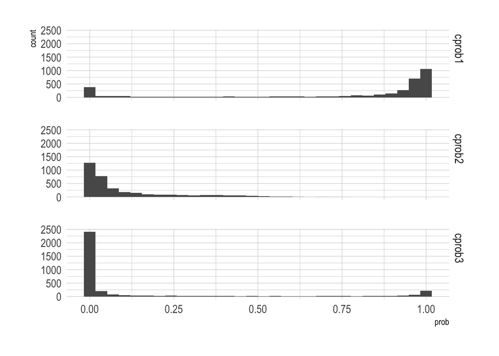

Distribution of the class probibilities from the cognition model by the most likely class

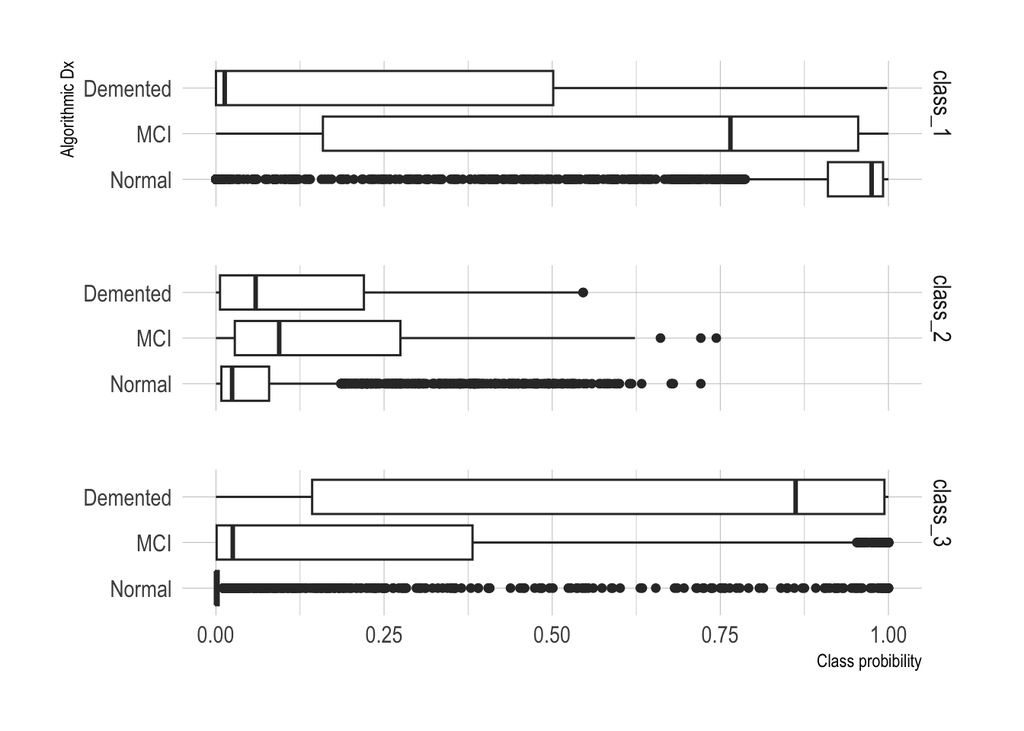

Distribution of class probabilities from the cognition model by Algorithmic Dx

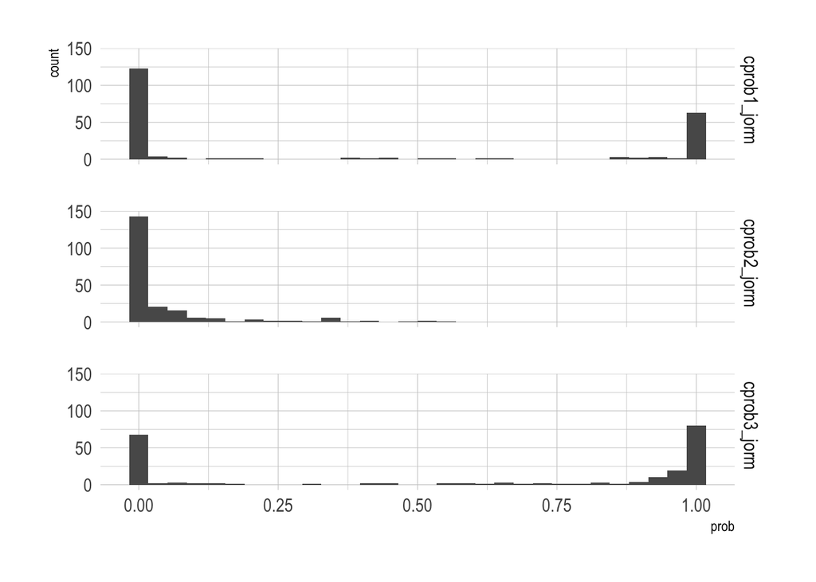

Distribution of the class probibilities from the Jorm model by the most likely class

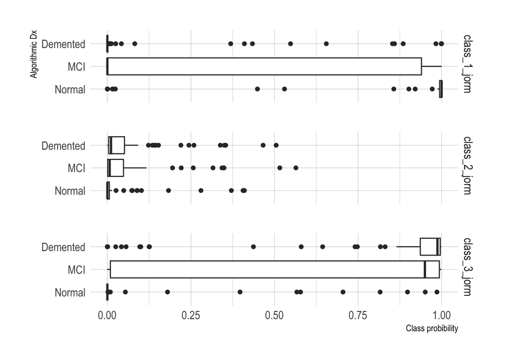

Distribution of class probabilities from the Jorm model by Algorithmic Dx

### Class assignment comparison

#### Comparison to Algorithmic Diagnosis

**Cognition model**

Most likely class membership (cognition model) vs algorithmic diagnosis, no sample weights

|  | Most likely class membership (cognition model) 1 | Most likely class membership (cognition model) 2 | Most likely class membership (cognition model) 3 | Total |  |
| --- | --- | --- | --- | --- | --- |
| HRS HCAP Dementia and MCI Classification (EAP version, HRS HCAP variable set 1) |  |  |  |  |  |
| 1 | 2,133 | 88 | 92 | 2,313 |  |
| 2 | 535 | 81 | 192 | 808 |  |
| 3 | 106 | 27 | 242 | 375 |  |
| Total | 2,774 | 196 | 526 | 3,496 |  |

Kappa: Most likely class membership (cognition model) vs algorithmic diagnosis, no sample weights

Cohen's weighted Kappa

| lower | estimate | upper |
| --- | --- | --- |
| 0.50 | 0.53 | 0.56 |

Most likely class membership (cognition model) vs algorithmic diagnosis, no sample weights

|  | Most likely class membership (2 level) (cognition model) Non-demented | Most likely class membership (2 level) (cognition model) Demented | Total |  |
| --- | --- | --- | --- | --- |
| HRS HCAP Dementia and MCI Classification (EAP version, HRS HCAP variable set 1) |  |  |  |  |
| Non-demented | 2,837 | 284 | 3,121 |  |
| Demented | 133 | 242 | 375 |  |
| Total | 2,970 | 526 | 3,496 |  |

Kappa: Most likely class membership (cognition model) vs algorithmic diagnosis, no sample weights

Cohen's weighted Kappa

| lower | estimate | upper |
| --- | --- | --- |
| 0.43 | 0.47 | 0.51 |

**Jorm model**

Most likely class membership (Jorm model) vs algorithmic diagnosis, no sample weights

|  | Most likely class membership (Jorm model) 1 | Most likely class membership (Jorm model) 2 | Most likely class membership (Jorm model) 3 | Total |  |
| --- | --- | --- | --- | --- | --- |
| HRS HCAP Dementia and MCI Classification (EAP version, HRS HCAP variable set 1) |  |  |  |  |  |
| 1 | 50 | 0 | 7 | 57 |  |
| 2 | 18 | 2 | 44 | 64 |  |
| 3 | 9 | 2 | 81 | 92 |  |
| Total | 77 | 4 | 132 | 213 |  |

Kappa: Most likely class membership (Jorm model) vs algorithmic diagnosis, no sample weights

Cohen's weighted Kappa

| lower | estimate | upper |
| --- | --- | --- |
| 0.53 | 0.62 | 0.72 |

Most likely class membership (Jorm model) vs algorithmic diagnosis, no sample weights

|  | Most likely class membership (2 level) (Jorm model) Non-demented | Most likely class membership (2 level) (Jorm model) Demented | Total |  |
| --- | --- | --- | --- | --- |
| HRS HCAP Dementia and MCI Classification (EAP version, HRS HCAP variable set 1) |  |  |  |  |
| Non-demented | 70 | 51 | 121 |  |
| Demented | 11 | 81 | 92 |  |
| Total | 81 | 132 | 213 |  |

Kappa: Most likely class membership (Jorm model) vs algorithmic diagnosis, no sample weights

Cohen's weighted Kappa

| lower | estimate | upper |
| --- | --- | --- |
| 0.33 | 0.44 | 0.55 |

Comparison of class membership between the cognition model and Jorm model

|  | Most likely class membership (Jorm model) 1 | Most likely class membership (Jorm model) 2 | Most likely class membership (Jorm model) 3 | Most likely class membership (Jorm model) Unknown | Total |  |
| --- | --- | --- | --- | --- | --- | --- |
| Most likely class membership (cognition model) |  |  |  |  |  |  |
| 1 | 71 | 0 | 0 | 2,703 | 2,774 |  |
| 2 | 0 | 0 | 0 | 196 | 196 |  |
| 3 | 6 | 4 | 132 | 384 | 526 |  |
| Total | 77 | 4 | 132 | 3,283 | 3,496 |  |

**Combined model**

Most likely class membership (combined model) vs algorithmic diagnosis, no sample weights

|  | Most likely class membership (combined model) 1 | Most likely class membership (combined model) 2 | Most likely class membership (combined model) 3 | Total |  |
| --- | --- | --- | --- | --- | --- |
| HRS HCAP Dementia and MCI Classification (EAP version, HRS HCAP variable set 1) |  |  |  |  |  |
| 1 | 2,137 | 88 | 88 | 2,313 |  |
| 2 | 535 | 83 | 190 | 808 |  |
| 3 | 108 | 29 | 238 | 375 |  |
| Total | 2,780 | 200 | 516 | 3,496 |  |

Kappa: Most likely class membership (combined model) vs algorithmic diagnosis, no sample weights

Cohen's weighted Kappa

| lower | estimate | upper |
| --- | --- | --- |
| 0.50 | 0.53 | 0.56 |

Most likely class membership (combined model) vs algorithmic diagnosis, no sample weights

|  | Most likely class membership (2 level) (combined model) Non-demented | Most likely class membership (2 level) (combined model) Demented | Total |  |
| --- | --- | --- | --- | --- |
| HRS HCAP Dementia and MCI Classification (EAP version, HRS HCAP variable set 1) |  |  |  |  |
| Non-demented | 2,843 | 278 | 3,121 |  |
| Demented | 137 | 238 | 375 |  |
| Total | 2,980 | 516 | 3,496 |  |

Kappa: Most likely class membership (combined model) vs algorithmic diagnosis, no sample weights

Cohen's weighted Kappa

| lower | estimate | upper |
| --- | --- | --- |
| 0.42 | 0.47 | 0.51 |

Most likely class membership (combined model) vs algorithmic diagnosis, 100 replications, no sample weights

|  | Most likely class membership (2 level) (combined model) Non-demented | Most likely class membership (2 level) (combined model) Demented | Total |  |
| --- | --- | --- | --- | --- |
| HRS HCAP Dementia and MCI Classification (EAP version, HRS HCAP variable set 1) |  |  |  |  |
| Non-demented | 282,068 | 30,032 | 312,100 |  |
| Demented | 14,459 | 23,041 | 37,500 |  |
| Total | 296,527 | 53,073 | 349,600 |  |

Kappa: Most likely class membership (combined model) vs algorithmic diagnosis, 100 replications, no sample weights

Cohen's weighted Kappa

| lower | estimate | upper |
| --- | --- | --- |
| 0.43 | 0.44 | 0.44 |

| HRS HCAP Dementia and MCI Classification (EAP version, HRS HCAP variable set 1) | Most likely class membership (combined model) Non-demented | Most likely class membership (combined model) Demented | Total |  |
| --- | --- | --- | --- | --- |
| Non-demented | 41,925,738 | 3,587,299 |  | 45,513,037 |
| Demented | 1,715,499 | 2,904,135 | 4,619,634 |  |
| Total | 43,641,237 | 6,491,434 | 50,132,671 |  |

Cohen's weighted Kappa

| lower | estimate | upper |
| --- | --- | --- |
| 0.46 | 0.47 | 0.47 |

#### Comparison to Langa-Weir

Model classification vs Langa-Weir diagnosis, 100 replications, with sample weights

| Langa-Weir classification | Most likely class membership (combined model) Non-demented | Most likely class membership (combined model) Demented | Total |  |
| --- | --- | --- | --- | --- |
| 1 | 42,628,026 | 3,558,485 |  | 46,186,511 |
| 2 | 1,013,211 | 2,932,949 | 3,946,160 |  |
| Total | 43,641,237 | 6,491,434 | 50,132,671 |  |

Kappa: Model classification vs Langa-Weir diagnosis, 100 replications, with sample weights

Cohen's weighted Kappa

| lower | estimate | upper |
| --- | --- | --- |
| 0.51 | 0.51 | 0.51 |

#### Comparison to Consensus panel

Model classification vs Consensus panel diagnosis, 100 replications, with sample weights

| Consensus panel classification | Most likely class membership (combined model) Non-demented | Most likely class membership (combined model) Demented | Total |  |
| --- | --- | --- | --- | --- |
| 1 | 93 | 3 |  | 96 |
| 2 | 1 | 4 | 5 |  |
| Total | 94 | 7 | 101 |  |

Kappa: Model classification vs Consensus diagnosis, 100 replications, with sample weights

Cohen's weighted Kappa

| lower | estimate | upper |
| --- | --- | --- |
| 0.33 | 0.65 | 0.97 |

## Weighted Comparison Tables

Comparisons that involve the consensus diagnosis use the HRS/HCAP validation-subsample weights computed as `HCAP16WGTR * samplingP^(-1)`.

Comparisons that do not involve the consensus diagnosis use the HCAP population weights `HCAP16WGTR`.

### Langa-Weir versus Consensus panel

Langa-Weir diagnosis vs Consensus panel diagnosis, with consensus-panel sample weights

| Langa-Weir classification | Consensus panel diagnosis Normal | Consensus panel diagnosis MCI | Consensus panel diagnosis Dementia | Total |  |
| --- | --- | --- | --- | --- | --- |
| Normal | 34.0 | 20.2 | 0.8 |  | 55.0 |
| MCI | 34.9 | 5.6 | 0.7 | 41.2 |  |
| Dementia | 0.0 | 0.6 | 3.1 | 3.7 |  |
| Total | 68.9 | 26.4 | 4.6 | 99.9 |  |

Note: This comparison uses the HRS/HCAP validation subsample. Weights are computed as HCAP16WGTR * samplingP^(-1) and are normalized within the consensus sample.

The quadratic weighted kappa is 0.099.

### Algorithmic diagnosis versus Consensus panel

Algorithmic diagnosis vs Consensus panel diagnosis, with consensus-panel sample weights

| Algorithmic diagnosis | Consensus panel diagnosis Normal | Consensus panel diagnosis MCI | Consensus panel diagnosis Dementia | Total |  |
| --- | --- | --- | --- | --- | --- |
| Normal | 68.8 | 13.5 | 0.0 |  | 82.3 |
| MCI | 0.1 | 6.7 | 0.3 | 7.1 |  |
| Dementia | 0.0 | 6.3 | 4.3 | 10.6 |  |
| Total | 68.9 | 26.5 | 4.6 | 100.0 |  |

Note: This comparison uses the HRS/HCAP validation subsample. Weights are computed as HCAP16WGTR * samplingP^(-1) and are normalized within the consensus sample.

The quadratic weighted kappa is 0.728.

### Langa-Weir versus Algorithmic diagnosis

Langa-Weir diagnosis vs Algorithmic diagnosis, with HCAP weights

| Algorithmic diagnosis | Langa-Weir diagnosis Normal | Langa-Weir diagnosis MCI | Langa-Weir diagnosis Dementia | Total |  |
| --- | --- | --- | --- | --- | --- |
| Normal | 30246474 | 4091218 | 450327 |  | 34788019 |
| MCI | 6069690 | 3120130 | 1535198 | 10725018 |  |
| Dementia | 1219788 | 1439211 | 1960635 | 4619634 |  |
| Total | 37535952 | 8650559 | 3946160 | 50132671 |  |

Note: This comparison uses the HCAP sample. Weights are the HCAP population weights HCAP16WGTR. This weighting differs from the weighting used for tables involving the consensus diagnosis.

The quadratic weighted kappa is 0.51.

### Consensus panel versus Combined model classification

Consensus panel diagnosis vs Combined model classification, with consensus-panel sample weights

| Consensus panel diagnosis | Combined model classification Normal | Combined model classification MCI | Combined model classification Dementia | Total |  |
| --- | --- | --- | --- | --- | --- |
| Normal | 59.9 | 7.0 | 2.0 |  | 68.9 |
| MCI | 13.1 | 6.3 | 7.1 | 26.5 |  |
| Dementia | 0.8 | 0.1 | 3.7 | 4.6 |  |
| Total | 73.8 | 13.4 | 12.8 | 100.0 |  |

Note: This comparison uses the HRS/HCAP validation subsample and the combined-model classification. Combined-model classifications are generated from the 100-replication sample implied by the combined-model class probabilities. The table weights are the consensus-sample weights HCAP16WGTR * samplingP^(-1), normalized within the consensus sample and divided by 100 across replications.

The quadratic weighted kappa is 0.528.

### Algorithmic diagnosis versus Combined model classification

Algorithmic diagnosis vs Combined model classification, with HCAP weights

| Algorithmic diagnosis | Combined model classification Normal | Combined model classification MCI | Combined model classification Dementia | Total |  |
| --- | --- | --- | --- | --- | --- |
| Normal | 30932079 | 2391440.6 | 1464500 |  | 34788019 |
| MCI | 6647418 | 1630996.6 | 2446603 | 10725018 |  |
| Dementia | 1206259 | 583978.1 | 2829397 | 4619634 |  |
| Total | 38785756 | 4606415.3 | 6740500 | 50132671 |  |

Note: This comparison uses the HCAP sample and the combined-model classification. Combined-model classifications are generated from the 100-replication sample implied by the combined-model class probabilities. The table weights are the HCAP population weights HCAP16WGTR divided by 100 across replications. This is not the same weighting used for the Langa-Weir versus algorithmic comparison, which uses the non-replicated HCAP weights.

The quadratic weighted kappa is 0.509.

### Langa-Weir versus Combined model classification

Langa-Weir diagnosis vs Combined model classification, with HCAP weights

| Langa-Weir classification | Combined model classification Normal | Combined model classification MCI | Combined model classification Dementia | Total |  |
| --- | --- | --- | --- | --- | --- |
| Normal | 33559303.7 | 2456902.7 | 1519746 |  | 37535952 |
| MCI | 4623052.7 | 1680160.1 | 2347346 | 8650559 |  |
| Dementia | 603399.7 | 469352.5 | 2873408 | 3946160 |  |
| Total | 38785756.1 | 4606415.3 | 6740500 | 50132671 |  |

Note: This comparison uses the HCAP sample and the combined-model classification. Combined-model classifications are generated from the 100-replication sample implied by the combined-model class probabilities. The table weights are the HCAP population weights HCAP16WGTR divided by 100 across replications. This is not the same weighting used for the Langa-Weir versus algorithmic comparison, which uses the non-replicated HCAP weights.

The quadratic weighted kappa is 0.583.

### Agreement Matrix

Pairwise quadratic weighted kappa matrix using consensus-panel weights for consensus comparisons and HCAP weights otherwise

| Consensus sample | Consensus diagnosis | Algorithmic diagnosis | Langa-Weir | Combined model |
| --- | --- | --- | --- | --- |
| Consensus diagnosis | 1.000 | 0.728 | 0.099 | 0.528 |
| Algorithmic diagnosis | 0.728 | 1.000 | 0.510 | 0.509 |
| Langa-Weir | 0.099 | 0.510 | 1.000 | 0.583 |
| Combined model | 0.528 | 0.509 | 0.583 | 1.000 |

Note: This matrix combines pairwise quadratic weighted kappas computed under different weighting schemes. Entries involving the consensus diagnosis use consensus-sample weights HCAP16WGTR * samplingP^(-1), normalized within the validation subsample. Entries not involving the consensus diagnosis use HCAP population weights HCAP16WGTR. Entries involving the combined model are computed on the 100-replication sample and therefore use replicated consensus-sample or replicated HCAP weights as appropriate.

## Dementia Versus Non-dementia

This section collapses Normal and MCI into a single non-demented category. Comparisons that involve the consensus diagnosis use consensus-panel weights, and comparisons that do not involve the consensus diagnosis use HCAP weights.

### Langa-Weir versus Consensus panel

Langa-Weir dementia classification vs Consensus panel diagnosis, with consensus-panel sample weights

| Langa-Weir classification | Consensus panel diagnosis Non-demented | Consensus panel diagnosis Demented | Total |  |
| --- | --- | --- | --- | --- |
| Non-demented | 94.8 | 1.5 |  | 96.3 |
| Demented | 0.6 | 3.1 | 3.7 |  |
| Total | 95.4 | 4.6 | 100.0 |  |

Note: This comparison uses the HRS/HCAP validation subsample. Weights are computed as HCAP16WGTR * samplingP^(-1) and are normalized within the consensus sample.

The kappa is 0.736.

### Algorithmic diagnosis versus Consensus panel

Algorithmic dementia classification vs Consensus panel diagnosis, with consensus-panel sample weights

| Algorithmic diagnosis | Consensus panel diagnosis Non-demented | Consensus panel diagnosis Demented | Total |  |
| --- | --- | --- | --- | --- |
| Non-demented | 89.1 | 0.3 |  | 89.4 |
| Demented | 6.3 | 4.3 | 10.6 |  |
| Total | 95.4 | 4.6 | 100.0 |  |

Note: This comparison uses the HRS/HCAP validation subsample. Weights are computed as HCAP16WGTR * samplingP^(-1) and are normalized within the consensus sample.

The kappa is 0.536.

### Langa-Weir versus Algorithmic diagnosis

Langa-Weir dementia classification vs Algorithmic diagnosis, with HCAP weights

| Algorithmic diagnosis | Langa-Weir diagnosis Non-demented | Langa-Weir diagnosis Demented | Total |  |
| --- | --- | --- | --- | --- |
| Non-demented | 43527512 | 1985525 |  | 45513037 |
| Demented | 2658999 | 1960635 | 4619634 |  |
| Total | 46186511 | 3946160 | 50132671 |  |

Note: This comparison uses the HCAP sample. Weights are the HCAP population weights HCAP16WGTR. This weighting differs from the weighting used for tables involving the consensus diagnosis.

The kappa is 0.407.

### Consensus panel versus Combined model classification

Consensus panel dementia classification vs Combined model classification, with consensus-panel sample weights

| Consensus panel diagnosis | Combined model classification Non-demented | Combined model classification Demented | Total |  |
| --- | --- | --- | --- | --- |
| Non-demented | 86.3 | 9.1 |  | 95.4 |
| Demented | 0.9 | 3.7 | 4.6 |  |
| Total | 87.2 | 12.8 | 100.0 |  |

Note: This comparison uses the HRS/HCAP validation subsample and the combined-model classification. Combined-model classifications are generated from the 100-replication sample implied by the combined-model class probabilities. The table weights are the consensus-sample weights HCAP16WGTR * samplingP^(-1), normalized within the consensus sample and divided by 100 across replications.

The kappa is 0.384.

### Algorithmic diagnosis versus Combined model classification

Algorithmic dementia classification vs Combined model classification, with HCAP weights

| Algorithmic diagnosis | Combined model classification Non-demented | Combined model classification Demented | Total |  |
| --- | --- | --- | --- | --- |
| Non-demented | 41601934 | 3911103 |  | 45513037 |
| Demented | 1790237 | 2829397 | 4619634 |  |
| Total | 43392171 | 6740500 | 50132671 |  |

Note: This comparison uses the HCAP sample and the combined-model classification. Combined-model classifications are generated from the 100-replication sample implied by the combined-model class probabilities. The table weights are the HCAP population weights HCAP16WGTR divided by 100 across replications. This is not the same weighting used for the Langa-Weir versus algorithmic comparison, which uses the non-replicated HCAP weights.

The kappa is 0.437.

### Langa-Weir versus Combined model classification

Langa-Weir dementia classification vs Combined model classification, with HCAP weights

| Langa-Weir classification | Combined model classification Non-demented | Combined model classification Demented | Total |  |
| --- | --- | --- | --- | --- |
| Non-demented | 42319419 | 3867092 |  | 46186511 |
| Demented | 1072752 | 2873408 | 3946160 |  |
| Total | 43392171 | 6740500 | 50132671 |  |

Note: This comparison uses the HCAP sample and the combined-model classification. Combined-model classifications are generated from the 100-replication sample implied by the combined-model class probabilities. The table weights are the HCAP population weights HCAP16WGTR divided by 100 across replications. This is not the same weighting used for the Langa-Weir versus algorithmic comparison, which uses the non-replicated HCAP weights.

The kappa is 0.487.

### Binary Agreement Matrix

Pairwise kappa matrix for dementia versus non-dementia using consensus-panel weights for consensus comparisons and HCAP weights otherwise

| Consensus sample | Consensus diagnosis | Algorithmic diagnosis | Langa-Weir | Combined model |
| --- | --- | --- | --- | --- |
| Consensus diagnosis | 1.000 | 0.536 | 0.736 | 0.384 |
| Algorithmic diagnosis | 0.536 | 1.000 | 0.407 | 0.437 |
| Langa-Weir | 0.736 | 0.407 | 1.000 | 0.487 |
| Combined model | 0.384 | 0.437 | 0.487 | 1.000 |

Note: This matrix combines pairwise kappas for dementia versus non-dementia computed under different weighting schemes. Entries involving the consensus diagnosis use consensus-sample weights HCAP16WGTR * samplingP^(-1), normalized within the validation subsample. Entries not involving the consensus diagnosis use HCAP population weights HCAP16WGTR. Entries involving the combined model are computed on the 100-replication sample and therefore use replicated consensus-sample or replicated HCAP weights as appropriate.

## Combined-Model Classification Margins

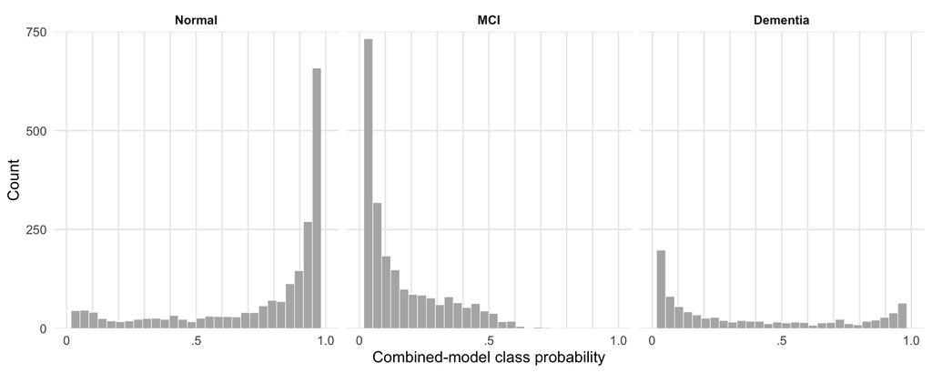

Histograms of combined-model class probabilities in the HRS/HCAP sample

Most likely combined-model class membership in the HRS/HCAP sample (N = 3496)

| Class | N | Weighted % |
| --- | --- | --- |
| Normal | 2,780 | 82.3 |
| MCI | 200 | 4.7 |
| Dementia | 516 | 12.9 |

Note: N and weighted percentages are computed in the non-replicated HRS/HCAP sample (N = 3496). Weighted percentages use HCAP16WGTR. Combined-model probabilities and most likely class assignments use the cognition-model and Jorm-model combination rule.

Langa-Weir class membership in the HRS/HCAP sample (N = 3496)

| Class | N | Weighted % |
| --- | --- | --- |
| Normal | 2,432 | 74.9 |
| MCI | 731 | 17.3 |
| Dementia | 333 | 7.9 |

Note: N and weighted percentages are computed in the non-replicated HRS/HCAP sample (N = 3496). Weighted percentages use HCAP16WGTR. Langa-Weir classifications come from cogfunction2016; category 2 is labeled MCI here for consistency with the rest of the report.

# References

Anthony, W. Z., Heaton, R. K., & Lehman, R. A. (1980). An attempt to cross-validate two actuarial systems for neuropsychological test interpretation. Journal of Consulting and Clinical Psychology, 48(3), 317.

Bondi, M. W., Jak, A. J., Delano-Wood, L., Jacobson, M. W., Delis, D. C., & Salmon, D. P. (2008). Neuropsychological contributions to the early identification of Alzheimer’s disease. Neuropsychology Review, 18, 73-90.

Bondi, M. W., Edmonds, E. C., Jak, A. J., Clark, L. R., Delano-Wood, L., McDonald, C. R., Nation, D. A., Libon, D. J., Au, R., & Galasko, D. (2014). Neuropsychological criteria for mild cognitive impairment improves diagnostic precision, biomarker associations, and progression rates. Journal of Alzheimer’s Disease, 42(1), 275-289.

Farron, M., Ryan, L. H., Manly, J. J., Levine, D. A., Plassman, B. L., Giordani, B. J., Jones, R. N., & Langa, K. M. (2025). Assessing Cognitive Impairment in the Health and Retirement Study Harmonized Cognitive Assessment Protocol Project: Comparing a Diagnostic Algorithm With a Diagnostic Consensus Panel. Journal of Aging and Health, 8982643251335370. https://doi.org/10.1177/08982643251335370

Fonda, S., & Herzog, A. R. (2004). Documentation of physical functioning measured in the Health and Retirement Study and the Asset and Health Dynamics among the Oldest Old Study. https://hrs.isr.umich.edu/sites/default/files/biblio/dr-008_0.pdf

Graves, L. V., Edmonds, E. C., Thomas, K. R., Weigand, A. J., Cooper, S., & Bondi, M. W. (2020). Evidence for the utility of actuarial neuropsychological criteria across the continuum of normal aging, mild cognitive impairment, and dementia. Journal of Alzheimer’s Disease, 78(1), 371-386.

Hudomiet, P., Hurd, M. D., & Rohwedder, S. (2022). Trends in inequalities in the prevalence of dementia in the United States. Proceedings of the National Academy of Sciences of the United States of America, 119(46), e2212205119. https://doi.org/10.1073/pnas.2212205119

Hurd, M. D., Martorell, P., Delavande, A., Mullen, K. J., & Langa, K. M. (2013). Monetary Costs of Dementia in the United States. The New England journal of medicine, 368(14), 1326-1334. https://doi.org/10.1056/NEJMsa1204629

Jack Jr, C. R., Bennett, D. A., Blennow, K., Carrillo, M. C., Dunn, B., Haeberlein, S. B., Holtzman, D. M., Jagust, W., Jessen, F., & Karlawish, J. (2018). NIA-AA research framework: toward a biological definition of Alzheimer’s disease. Alzheimer’s & Dementia, 14(4), 535-562.

Jak, A. J., Bondi, M. W., Delano-Wood, L., Wierenga, C., Corey-Bloom, J., Salmon, D. P., & Delis, D. C. (2009). Quantification of five neuropsychological approaches to defining mild cognitive impairment. The American Journal of Geriatric Psychiatry, 17(5), 368-375.

Jones, R. N., Manly, J. J., Langa, K. M., Ryan, L. H., Levine, D. A., McCammon, R., & Weir, D. (2024). Factor structure of the Harmonized Cognitive Assessment Protocol neuropsychological battery in the Health and Retirement Study. Journal of the International Neuropsychological Society, 30(1), 47-55. https://doi.org/10.1017/S135561772300019X

Langa, K. M., Ryan, L. H., McCammon, R. J., Jones, R. N., Manly, J. J., Levine, D. A., Sonnega, A., Farron, M., & Weir, D. R. (2020). The Health and Retirement Study Harmonized Cognitive Assessment Protocol Project: Study Design and Methods. Neuroepidemiology, 54(1), 64-74. https://doi.org/10.1159/000503004

Langa, K. M., Weir, D. R., Kabeto, M., & Sonnega, A. (2023). Langa-Weir Classification of Cognitive Function (1995-2000). https://hrsdata.isr.umich.edu/sites/default/files/documentation/data-descriptions/1695907706/Data_Description_Langa_Weir_Classifications2020_V2.pdf

Manly, J. J., Jones, R. N., Langa, K. M., Ryan, L. H., Levine, D. A., McCammon, R., Heeringa, S. G., & Weir, D. (2022). Estimating the Prevalence of Dementia and Mild Cognitive Impairment in the US: The 2016 Health and Retirement Study Harmonized Cognitive Assessment Protocol Project. JAMA Neurol, 79(12), 1242-1249. https://doi.org/10.1001/jamaneurol.2022.3543

Meehl, P. E. (1954). Clinical versus statistical prediction: A theoretical analysis and a review of the evidence. University of Minnesota Press. https://doi.org/https://doi.org/10.1037/11281-000

Wu, Q., Tchetgen, E. J. T., Osypuk, T. L., White, K., Mujahid, M., & Glymour, M. M. (2013). Combining direct and proxy assessments to reduce attrition bias in a longitudinal study. Alzheimer Disease and Associated Disorders, 27(3), 207-212.